# SeekAce Assignment No. : 1

## Vipendra Pal Rajput

#### Data Description: Income : Income of the individual Limit : Limit of the card issued Rating : Credit Rating of the individual Cards : No of cards issued Age : Age of the individual Locality : Area of Residence of an individual Education : Number of years of education applicant have Gender : Gender of an individual Student : Whether an individual is a student at time of application Married : Is the individual married Ethnicity : To which ethnicity an individual belongs to Balance : Credit remaining in the card Employment : Type of employment of an individual

```python
# Import necessary librearies

import pandas as pd
import numpy as np
from matplotlib import pyplot as plt
import seaborn as sns
```

```python
# Read CSV file and store in a new variable

df = pd.read_csv('Credit.csv')
df
```

|  | Income | Limit | Rating | Cards | Age | Locality | Education | Gender | Student | Married | Ethnicity | Balance | Employment |
| --- | --- | --- | --- | --- | --- | --- | --- | --- | --- | --- | --- | --- | --- |
| 0 | 14.891 | 3606.0 | NaN | 2.0 | 34 | NaN | 11.0 | Male | No | Yes | Caucasian | 333.0 | Business |
| 1 | 106.025 | 6645.0 | 483 | 3.0 | 82 | NaN | 15.0 | Female | Yes | Yes | Asian | 903.0 | NaN |
| 2 | 104.593 | 7075.0 | 514 | 4.0 | 71 | NaN | 11.0 | Male | No | No | Asian | 580.0 | NaN |
| 3 | 148.924 | 9504.0 | 681 | 3.0 | 36 | NaN | 11.0 | Female | No | No | Asian | 964.0 | NaN |
| 4 | 55.882 | 4897.0 | 357 | 2.0 | 68 | NaN | 16.0 | Male | No | Yes | Caucasian | 331.0 | NaN |
| ... | ... | ... | ... | ... | ... | ... | ... | ... | ... | ... | ... | ... | ... |
| 408 | 62.602 | 7056.0 | 481 | 1.0 | 84 | NaN | 11.0 | Female | No | No | Caucasian | 904.0 | NaN |
| 409 | 29.564 | 2529.0 | 192 | 1.0 | 30 | NaN | 12.0 | Female | No | Yes | Caucasian | 0.0 | NaN |
| 410 | 35.864 | 4831.0 | 353 | 3.0 | 66 | NaN | 13.0 | Female | No | Yes | Caucasian | 534.0 | NaN |
| 411 | 19.537 | 1362.0 | 143 | 4.0 | 34 | NaN | 9.0 | Female | No | Yes | Asian | 0.0 | NaN |
| 412 | 30.42 | 4442.0 | 316 | 1.0 | 30 | NaN | 14.0 | Female | No | No | African American | 450.0 | NaN |

413 rows × 13 columns

# From Pyhton cell 3 to 80 is data cleaning steps

```python
# Making copy of dataframe, so our original data remain same. When we need then we can access.

ds = df.copy()
```

```python
# Checking null values

ds.isnull().sum()
```

```
Income          4
Limit           5
Rating          4
Cards           5
Age             5
Locality      397
Education       2
Gender          2
Student         3
Married         2
Ethnicity       7
Balance         4
Employment    404
dtype: int64
```

```python
# Count how many times value is repeated or comes

ds['Locality'].value_counts()
```

```
city       9
Village    7
Name: Locality, dtype: int64
```

```python
# Count how many times value is repeated or comes

ds['Employment'].value_counts()
```

```
Service     5
Business    4
Name: Employment, dtype: int64
```

### After checking Null Values we find two columns have Maxmium Null value and hence these column cann't be good for predict or getting output so drop them

```python
# Drop Column that have max Null Values

d1 = ds.drop(['Employment','Locality'], axis=1)
d1
```

|  | Income | Limit | Rating | Cards | Age | Education | Gender | Student | Married | Ethnicity | Balance |
| --- | --- | --- | --- | --- | --- | --- | --- | --- | --- | --- | --- |
| 0 | 14.891 | 3606.0 | NaN | 2.0 | 34 | 11.0 | Male | No | Yes | Caucasian | 333.0 |
| 1 | 106.025 | 6645.0 | 483 | 3.0 | 82 | 15.0 | Female | Yes | Yes | Asian | 903.0 |
| 2 | 104.593 | 7075.0 | 514 | 4.0 | 71 | 11.0 | Male | No | No | Asian | 580.0 |
| 3 | 148.924 | 9504.0 | 681 | 3.0 | 36 | 11.0 | Female | No | No | Asian | 964.0 |
| 4 | 55.882 | 4897.0 | 357 | 2.0 | 68 | 16.0 | Male | No | Yes | Caucasian | 331.0 |
| ... | ... | ... | ... | ... | ... | ... | ... | ... | ... | ... | ... |
| 408 | 62.602 | 7056.0 | 481 | 1.0 | 84 | 11.0 | Female | No | No | Caucasian | 904.0 |
| 409 | 29.564 | 2529.0 | 192 | 1.0 | 30 | 12.0 | Female | No | Yes | Caucasian | 0.0 |
| 410 | 35.864 | 4831.0 | 353 | 3.0 | 66 | 13.0 | Female | No | Yes | Caucasian | 534.0 |
| 411 | 19.537 | 1362.0 | 143 | 4.0 | 34 | 9.0 | Female | No | Yes | Asian | 0.0 |
| 412 | 30.42 | 4442.0 | 316 | 1.0 | 30 | 14.0 | Female | No | No | African American | 450.0 |

413 rows × 11 columns

```python
# Check Duplicate values

d1[d1.duplicated(keep=False)]
```

|  | Income | Limit | Rating | Cards | Age | Education | Gender | Student | Married | Ethnicity | Balance |
| --- | --- | --- | --- | --- | --- | --- | --- | --- | --- | --- | --- |
| 8 | 15.125 | 3300.0 | 266 | 5.0 | 66 | 13.0 | Female | No | No | Caucasian | 279.0 |
| 13 | 43.682 | 6922.0 | 511 | 1.0 | 49 | 9.0 | Male | No | Yes | Caucasian | 1081.0 |
| 27 | 32.793 | 4534.0 | 333 | 2.0 | 44 | 16.0 | Male | No | No | African American | 467.0 |
| 38 | 11.795 | 3899.0 | 300 | 4.0 | 25 | 10.0 | Female | No | No | Caucasian | 531.0 |
| 75 | 33.017 | 3180.0 | 224 | 2.0 | 28 | 16.0 | Male | No | Yes | African American | 29.0 |
| 117 | 91.362 | 9113.0 | 626 | 1.0 | 47 | 17.0 | Male | No | Yes | Asian | 1341.0 |
| 120 | 27.241 | 1402.0 | 128 | 2.0 | 67 | 15.0 | Female | No | Yes | Asian | 0.0 |
| 122 | 62.602 | 7056.0 | 481 | 1.0 | 84 | 11.0 | Female | No | No | Caucasian | 904.0 |
| 124 | 29.564 | 2529.0 | 192 | 1.0 | 30 | 12.0 | Female | No | Yes | Caucasian | 0.0 |
| 151 | 35.864 | 4831.0 | 353 | 3.0 | 66 | 13.0 | Female | No | Yes | Caucasian | 534.0 |
| 155 | 19.537 | 1362.0 | 143 | 4.0 | 34 | 9.0 | Female | No | Yes | Asian | 0.0 |
| 185 | 30.42 | 4442.0 | 316 | 1.0 | 30 | 14.0 | Female | No | No | African American | 450.0 |
| 400 | 15.125 | 3300.0 | 266 | 5.0 | 66 | 13.0 | Female | No | No | Caucasian | 279.0 |
| 401 | 43.682 | 6922.0 | 511 | 1.0 | 49 | 9.0 | Male | No | Yes | Caucasian | 1081.0 |
| 402 | 32.793 | 4534.0 | 333 | 2.0 | 44 | 16.0 | Male | No | No | African American | 467.0 |
| 403 | 11.795 | 3899.0 | 300 | 4.0 | 25 | 10.0 | Female | No | No | Caucasian | 531.0 |
| 404 | 33.017 | 3180.0 | 224 | 2.0 | 28 | 16.0 | Male | No | Yes | African American | 29.0 |
| 406 | 91.362 | 9113.0 | 626 | 1.0 | 47 | 17.0 | Male | No | Yes | Asian | 1341.0 |
| 407 | 27.241 | 1402.0 | 128 | 2.0 | 67 | 15.0 | Female | No | Yes | Asian | 0.0 |
| 408 | 62.602 | 7056.0 | 481 | 1.0 | 84 | 11.0 | Female | No | No | Caucasian | 904.0 |
| 409 | 29.564 | 2529.0 | 192 | 1.0 | 30 | 12.0 | Female | No | Yes | Caucasian | 0.0 |
| 410 | 35.864 | 4831.0 | 353 | 3.0 | 66 | 13.0 | Female | No | Yes | Caucasian | 534.0 |
| 411 | 19.537 | 1362.0 | 143 | 4.0 | 34 | 9.0 | Female | No | Yes | Asian | 0.0 |
| 412 | 30.42 | 4442.0 | 316 | 1.0 | 30 | 14.0 | Female | No | No | African American | 450.0 |

```python
# Drop Duplicate value rows

d1.drop_duplicates(inplace=True)
```

```python
# Now again check null values

d1.isnull().sum()
```

```
Income       4
Limit        5
Rating       4
Cards        5
Age          5
Education    2
Gender       2
Student      3
Married      2
Ethnicity    7
Balance      4
dtype: int64
```

```python
# Check whole info of our DataFrame so we can get datatype and many more info from DataFrame

d1.info()
```

```
<class 'pandas.core.frame.DataFrame'>
Int64Index: 401 entries, 0 to 405
Data columns (total 11 columns):
Income       397 non-null object
Limit        396 non-null float64
Rating       397 non-null object
Cards        396 non-null float64
Age          396 non-null object
Education    399 non-null float64
Gender       399 non-null object
Student      398 non-null object
Married      399 non-null object
Ethnicity    394 non-null object
Balance      397 non-null float64
dtypes: float64(4), object(7)
memory usage: 37.6+ KB
```

```python
# Access column from DataFrame

d1['Income']
```

```
0       14.891
1      106.025
2      104.593
3      148.924
4       55.882
        ...
396     13.364
397     57.872
398     37.728
399     18.701
405     11.741
Name: Income, Length: 401, dtype: object
```

```python
# Count how many times value is repeated or comes

d1['Income'].value_counts()
```

```
11.741    2
23.793    2
21.374    1
33.694    1
13.676    1
         ..
11.603    1
94.193    1
60.449    1
25.124    1
16.304    1
Name: Income, Length: 395, dtype: int64
```

```python
# To check or get unique values from column

d1['Income'].unique()
```

```
array(['14.891', '106.025', '104.593', '148.924', '55.882', '80.18',
       '20.996', '71.41%', '15.125', '71.061', '63.095', '15.04&5',
       '80.616', '43.682', '$19.144', '20.089', '53.598', '36.496',
       '49.57', '42.079', '$17.7', '37.348', '20.103', '64.027', '10.742',
       '14.09', '42.471', '32.793', '186.634', '26.813', '34.142',
       '28.941', '134.181', '31.367', '20.15', '23.35', '62.413',
       '30.007', '11.795', '13.647', '34.95', '113.659', '44.158',
       '36.929', '31.861', '77.38', '19.531', '44.646', '44.522',
       '43.479', '36.362', '39.705', '44.205', '16.304', '15.333',
       '32.916', '57.1', '76.273', '10.354', '51.872', '35.51', '$21.238',
       '30.682', '14.132', '32.164', '12', '113.829', '11.187', '27.847',
       '49.502', '24.889', '58.781', '22.939', '23.989', '16.103',
       '33.017', '30.622', '20.936', '110.968', '15.354', '27.369', nan,
       '23.672', '19.225', '43.54', '152.298', '55.367', '11.741',
       '15.56', '59.53', '20.191', '48.498', '30.733', '16.479', '38.009',
       '14.084', '14.312', '26.067', '36.295', '83.851', '21.153',
       '17.976', '68.713', '146.183', '15.846', '12.031', '16.819',
       '39.11', '107.986', '13.561', '34.537', '28.575', '46.007',
       '69.251', '16.482', '40.442', '35.177', '91.362', '27.039',
       '23.012', '27.241', '148.08', '62.602', '11.808', '29.564',
       '27.578', '26.427', '57.202', '123.299', '18.145', '23.793',
       '10.726', '23.283', '21.455', '34.664', '44.473', '54.663',
       '36.355', '21.374', '107.841', '39.831', '91.876', '103.893',
       '19.636', '17.392', '19.529', '17.055', '15.184', '13.444',
       '63.931', '35.864', '41.419', '92.112', '55.056', '19.537',
       '31.811', '42.357', '53.319', '12.238', '31.353', '63.809',
       '13.676', '76.782', '25.383', '35.691', '29.403', '27.47', '27.33',
       '34.772', '36.934', '76.348', '14.887', '121.834', '30.132',
       '24.05', '22.379', '28.316', '58.026', '10.635', '46.102',
       '58.929', '80.861', '158.889', '30.42', '36.472', '23.365',
       '83.869', '58.351', '55.187', '124.29', '28.508', '130.209',
       '30.406', '23.883', '93.039', '50.699', '27.349', '10.403',
       '23.949', '73.914', '21.038', '68.206', '57.337', '10.793',
       '23.45', '10.842', '51.345', '151.947', '24.543', '29.567',
       '39.145', '39.422', '34.909', '41.025', '15.476', '12.456',
       '10.627', '38.954', '44.847', '98.515', '33.437', '27.512',
       '121.709', '15.079', '59.879', '66.989', '69.165', '69.943',
       '33.214', '25.124', '15.741', '11.603', '69.656', '10.503',
       '42.529', '60.579', '26.532', '27.952', '29.705', '15.602',
       '20.918', '58.165', '22.561', '34.509', '19.588', '36.364',
```

[output cut: 10 more lines]

```
       '33.694', '23.375', '27.825', '92.386', '115.52', '14.479',
       '52.179', '68.462', '18.951', '27.59', '16.279', '25.078',
       '27.229', '182.728', '31.029', '17.765', '125.48', '49.166',
       '41.192', '94.193', '20.405', '12.581', '62.328', '21.011',
       '24.23', '24.314', '32.856', '12.414', '41.365', '149.316',
       '27.794', '13.234', '14.595', '10.735', '48.218', '30.012',
       '21.551', '160.231', '13.433', '48.577', '30.002', '61.62',
       '104.483', '41.868', '12.068', '180.682', '34.48', '39.609',
       '30.111', '12.335', '53.566', '53.217', '26.162', '64.173',
       '128.669', '113.772', '61.069', '89', '71.682', '35.61', '39.116',
       '19.782', '55.412', '29.4', '20.974', '87.625', '28.144', '19.349',
       '53.308', '115.123', '24.824', '14.292', '20.088', '26.4',
       '19.253', '16.529', '37.878', '83.948', '135.118', '73.327',
       '25.974', '17.316', '49.794', '12.096', '13.364', '57.872',
       '37.728', '18.701'], dtype=object)
```

```python
# get NaN value from DataFrame

d1[d1['Income'].isna()]
```

|  | Income | Limit | Rating | Cards | Age | Education | Gender | Student | Married | Ethnicity | Balance |
| --- | --- | --- | --- | --- | --- | --- | --- | --- | --- | --- | --- |
| 81 | NaN | 4263.0 | 317 | 1.0 | 83 | 15.0 | Male | no | no | Caucasian | 99.0 |
| 147 | NaN | 1501.0 | 150 | 3.0 | 56 | 16.0 | Male | No | Yes | Caucasian | 0.0 |
| 157 | NaN | 5521.0 | 406 | 2.0 | 72 | 16.0 | Female | Yes | Yes | Caucasian | 1020.0 |
| 381 | NaN | 8029.0 | 574 | 2.0 | 84 | 11.0 | Male | No | Yes | Caucasian | 849.0 |

```python
d1.head(20)
```

|  | Income | Limit | Rating | Cards | Age | Education | Gender | Student | Married | Ethnicity | Balance |
| --- | --- | --- | --- | --- | --- | --- | --- | --- | --- | --- | --- |
| 0 | 14.891 | 3606.0 | NaN | 2.0 | 34 | 11.0 | Male | No | Yes | Caucasian | 333.0 |
| 1 | 106.025 | 6645.0 | 483 | 3.0 | 82 | 15.0 | Female | Yes | Yes | Asian | 903.0 |
| 2 | 104.593 | 7075.0 | 514 | 4.0 | 71 | 11.0 | Male | No | No | Asian | 580.0 |
| 3 | 148.924 | 9504.0 | 681 | 3.0 | 36 | 11.0 | Female | No | No | Asian | 964.0 |
| 4 | 55.882 | 4897.0 | 357 | 2.0 | 68 | 16.0 | Male | No | Yes | Caucasian | 331.0 |
| 5 | 80.18 | 8047.0 | 569 | 4.0 | 77 | 10.0 | Male | No | No | Caucasian | 1151.0 |
| 6 | 20.996 | 3388.0 | 259 | 2.0 | 37 | 12.0 | Female | No | No | African American | 203.0 |
| 7 | 71.41% | 7114.0 | 512 | 2.0 | 87 | 9.0 | Male | No | No | Asian | 872.0 |
| 8 | 15.125 | 3300.0 | 266 | 5.0 | 66 | 13.0 | Female | No | No | Caucasian | 279.0 |
| 9 | 71.061 | 6819.0 | 491 | 3.0 | 41 | 19.0 | Female | Yes | Yes | African American | 1350.0 |
| 10 | 63.095 | 8117.0 | 589 | 4.0 | 30 | 14.0 | Male | No | Yes | Caucasian | 1407.0 |
| 11 | 15.04&5 | 1311.0 | 138 | 3.0 | 64 | 16.0 | Male | No | No | Caucasian | 0.0 |
| 12 | 80.616 | 5308.0 | 394 | 1.0 | 57 | 7.0 | Female | No | Yes | Asian | 204.0 |
| 13 | 43.682 | 6922.0 | 511 | 1.0 | 49 | 9.0 | Male | No | Yes | Caucasian | 1081.0 |
| 14 | $19.144 | 3291.0 | 269 | NaN | 75 | 13.0 | Female | No | No | African American | 148.0 |
| 15 | 20.089 | 2525.0 | 200 | 3.0 | 57 | 151.0 | Female | No | Yes | African American | 0.0 |
| 16 | 53.598 | 3714.0 | 286 | 3.0 | 73 | 17.0 | Female | No | Yes | African American | 0.0 |
| 17 | 36.496 | 4378.0 | 339 | NaN | 69 | 15.0 | Female | No | Yes | Asian | 368.0 |
| 18 | 49.57 | 6384.0 | 448 | 1.0 | 28 | 9.0 | Female | No | Yes | Asian | 891.0 |
| 19 | 42.079 | 6626.0 | 479 | 2.0 | 244 | 9.0 | Male | No | No | Asian | 1048.0 |

```python
# Making dictionary so we can replace some words

dictionary = {'%':'','\$':'','&':'','$':''}
dictionary
```

```
{'%': '', '\\$': '', '&': '', '$': ''}
```

```python
# Replace the dictionarywords

d1.replace(dictionary, regex=True, inplace=True)
```

```python
d1.head(20)
```

|  | Income | Limit | Rating | Cards | Age | Education | Gender | Student | Married | Ethnicity | Balance |
| --- | --- | --- | --- | --- | --- | --- | --- | --- | --- | --- | --- |
| 0 | 14.891 | 3606.0 | NaN | 2.0 | 34 | 11.0 | Male | No | Yes | Caucasian | 333.0 |
| 1 | 106.025 | 6645.0 | 483 | 3.0 | 82 | 15.0 | Female | Yes | Yes | Asian | 903.0 |
| 2 | 104.593 | 7075.0 | 514 | 4.0 | 71 | 11.0 | Male | No | No | Asian | 580.0 |
| 3 | 148.924 | 9504.0 | 681 | 3.0 | 36 | 11.0 | Female | No | No | Asian | 964.0 |
| 4 | 55.882 | 4897.0 | 357 | 2.0 | 68 | 16.0 | Male | No | Yes | Caucasian | 331.0 |
| 5 | 80.18 | 8047.0 | 569 | 4.0 | 77 | 10.0 | Male | No | No | Caucasian | 1151.0 |
| 6 | 20.996 | 3388.0 | 259 | 2.0 | 37 | 12.0 | Female | No | No | African American | 203.0 |
| 7 | 71.41 | 7114.0 | 512 | 2.0 | 87 | 9.0 | Male | No | No | Asian | 872.0 |
| 8 | 15.125 | 3300.0 | 266 | 5.0 | 66 | 13.0 | Female | No | No | Caucasian | 279.0 |
| 9 | 71.061 | 6819.0 | 491 | 3.0 | 41 | 19.0 | Female | Yes | Yes | African American | 1350.0 |
| 10 | 63.095 | 8117.0 | 589 | 4.0 | 30 | 14.0 | Male | No | Yes | Caucasian | 1407.0 |
| 11 | 15.045 | 1311.0 | 138 | 3.0 | 64 | 16.0 | Male | No | No | Caucasian | 0.0 |
| 12 | 80.616 | 5308.0 | 394 | 1.0 | 57 | 7.0 | Female | No | Yes | Asian | 204.0 |
| 13 | 43.682 | 6922.0 | 511 | 1.0 | 49 | 9.0 | Male | No | Yes | Caucasian | 1081.0 |
| 14 | 19.144 | 3291.0 | 269 | NaN | 75 | 13.0 | Female | No | No | African American | 148.0 |
| 15 | 20.089 | 2525.0 | 200 | 3.0 | 57 | 151.0 | Female | No | Yes | African American | 0.0 |
| 16 | 53.598 | 3714.0 | 286 | 3.0 | 73 | 17.0 | Female | No | Yes | African American | 0.0 |
| 17 | 36.496 | 4378.0 | 339 | NaN | 69 | 15.0 | Female | No | Yes | Asian | 368.0 |
| 18 | 49.57 | 6384.0 | 448 | 1.0 | 28 | 9.0 | Female | No | Yes | Asian | 891.0 |
| 19 | 42.079 | 6626.0 | 479 | 2.0 | 244 | 9.0 | Male | No | No | Asian | 1048.0 |

```python
# Converting column value datatype object to float

d1['Income'] = d1['Income'].astype(float)
```

```python
# Get max, min median std and many more information using describe()

d1.Income.describe()
```

```
count    397.000000
mean      44.997270
std       35.279414
min       10.354000
25%       20.974000
50%       32.916000
75%       57.337000
max      186.634000
Name: Income, dtype: float64
```

```python
# Fillna values by mean of Income column

d2 = d1.fillna({'Income':d1['Income'].mean()})
d2
```

|  | Income | Limit | Rating | Cards | Age | Education | Gender | Student | Married | Ethnicity | Balance |
| --- | --- | --- | --- | --- | --- | --- | --- | --- | --- | --- | --- |
| 0 | 14.891 | 3606.0 | NaN | 2.0 | 34 | 11.0 | Male | No | Yes | Caucasian | 333.0 |
| 1 | 106.025 | 6645.0 | 483 | 3.0 | 82 | 15.0 | Female | Yes | Yes | Asian | 903.0 |
| 2 | 104.593 | 7075.0 | 514 | 4.0 | 71 | 11.0 | Male | No | No | Asian | 580.0 |
| 3 | 148.924 | 9504.0 | 681 | 3.0 | 36 | 11.0 | Female | No | No | Asian | 964.0 |
| 4 | 55.882 | 4897.0 | 357 | 2.0 | 68 | 16.0 | Male | No | Yes | Caucasian | 331.0 |
| ... | ... | ... | ... | ... | ... | ... | ... | ... | ... | ... | ... |
| 396 | 13.364 | 3838.0 | 296 | 5.0 | 65 | 17.0 | Male | No | No | African American | 480.0 |
| 397 | 57.872 | 4171.0 | 321 | 5.0 | 67 | 12.0 | Female | No | Yes | Caucasian | 138.0 |
| 398 | 37.728 | 2525.0 | 192 | 1.0 | 44 | 13.0 | Male | No | Yes | Caucasian | 0.0 |
| 399 | 18.701 | 5524.0 | 415 | 5.0 | 64 | 7.0 | Female | No | No | Asian | 966.0 |
| 405 | 11.741 | 2271.0 | 182 | 4.0 | 59 | 12.0 | Female | No | No | NaN | 0.0 |

401 rows × 11 columns

```python
# Count how many times value is repeated or comes

d2['Limit'].value_counts()
```

```
6819.0    2
2525.0    2
5140.0    2
3461.0    2
4391.0    2
         ..
9560.0    1
1501.0    1
3613.0    1
5180.0    1
3606.0    1
Name: Limit, Length: 382, dtype: int64
```

```python
# Get max, min median std and many more information using describe()

d2.Limit.describe()
```

```
count      396.000000
mean      4747.732323
std       2311.462152
min        855.000000
25%       3094.250000
50%       4636.000000
75%       5885.750000
max      13913.000000
Name: Limit, dtype: float64
```

```python
# get NaN value from DataFrame

d2[d2['Limit'].isna()]
```

|  | Income | Limit | Rating | Cards | Age | Education | Gender | Student | Married | Ethnicity | Balance |
| --- | --- | --- | --- | --- | --- | --- | --- | --- | --- | --- | --- |
| 54 | 15.333 | NaN | 138 | 2.0 | 47 | 9.0 | Female | No | Yes | Asian | 0.0 |
| 94 | 38.009 | NaN | 245 | 3.0 | 45 | 15.0 | Female | No | No | African American | 0.0 |
| 134 | 34.664 | NaN | 452 | 3.0 | 77 | 15.0 | Female | No | Yes | African American | 835.0 |
| 167 | 29.403 | NaN | 178 | 1.0 | 37 | 14.0 | Female | No | Yes | Caucasian | 0.0 |
| 328 | 41.192 | NaN | 297 | 3.0 | 54 | 16.0 | Female | No | Yes | Caucasian | 121.0 |

```python
# Fillna values by mean of Limit column because to fillna we need average of the limit

d3 = d2.fillna({'Limit':d2['Limit'].mean()})
d3
```

|  | Income | Limit | Rating | Cards | Age | Education | Gender | Student | Married | Ethnicity | Balance |
| --- | --- | --- | --- | --- | --- | --- | --- | --- | --- | --- | --- |
| 0 | 14.891 | 3606.0 | NaN | 2.0 | 34 | 11.0 | Male | No | Yes | Caucasian | 333.0 |
| 1 | 106.025 | 6645.0 | 483 | 3.0 | 82 | 15.0 | Female | Yes | Yes | Asian | 903.0 |
| 2 | 104.593 | 7075.0 | 514 | 4.0 | 71 | 11.0 | Male | No | No | Asian | 580.0 |
| 3 | 148.924 | 9504.0 | 681 | 3.0 | 36 | 11.0 | Female | No | No | Asian | 964.0 |
| 4 | 55.882 | 4897.0 | 357 | 2.0 | 68 | 16.0 | Male | No | Yes | Caucasian | 331.0 |
| ... | ... | ... | ... | ... | ... | ... | ... | ... | ... | ... | ... |
| 396 | 13.364 | 3838.0 | 296 | 5.0 | 65 | 17.0 | Male | No | No | African American | 480.0 |
| 397 | 57.872 | 4171.0 | 321 | 5.0 | 67 | 12.0 | Female | No | Yes | Caucasian | 138.0 |
| 398 | 37.728 | 2525.0 | 192 | 1.0 | 44 | 13.0 | Male | No | Yes | Caucasian | 0.0 |
| 399 | 18.701 | 5524.0 | 415 | 5.0 | 64 | 7.0 | Female | No | No | Asian | 966.0 |
| 405 | 11.741 | 2271.0 | 182 | 4.0 | 59 | 12.0 | Female | No | No | NaN | 0.0 |

401 rows × 11 columns

```python
# Access column from DataFrame

d3['Rating']
```

```
0      NaN
1      483
2      514
3      681
4      357
      ...
396    296
397    321
398    192
399    415
405    182
Name: Rating, Length: 401, dtype: object
```

```python
# Count how many times value is repeated or comes

d3['Rating'].value_counts()
```

```
344    5
296    4
383    4
287    4
380    3
      ..
379    1
134    1
171    1
278    1
241    1
Name: Rating, Length: 281, dtype: int64
```

```python
# get NaN value from DataFrame

d3[d3['Rating'].isna()]
```

|  | Income | Limit | Rating | Cards | Age | Education | Gender | Student | Married | Ethnicity | Balance |
| --- | --- | --- | --- | --- | --- | --- | --- | --- | --- | --- | --- |
| 0 | 14.891 | 3606.0 | NaN | 2.0 | 34 | 11.0 | Male | No | Yes | Caucasian | 333.0 |
| 78 | 110.968 | 6662.0 | NaN | 3.0 | 45 | 11.0 | Female | No | Yes | Caucasian | 391.0 |
| 127 | 57.202 | 3411.0 | NaN | 3.0 | 72 | 11.0 | Female | No | No | Caucasian | 0.0 |
| 311 | 23.375 | 5429.0 | NaN | 3.0 | 57 | 15.0 | Female | No | Yes | Caucasian | 844.0 |

```python
# Replace values using .replace() method

d3['Rating'] = d3['Rating'].replace(['352s'],'352')
```

```python
# Converting column value datatype object to float

d3['Rating'] = d3['Rating'].astype(float)
```

```python
# Get max, min median std and many more information using describe()

d3.Rating.describe()
```

```
count    397.000000
mean     354.539043
std      155.317211
min       93.000000
25%      243.000000
50%      344.000000
75%      437.000000
max      982.000000
Name: Rating, dtype: float64
```

```python
# Fillna values by mean of Rating column

d4 = d3.fillna({'Rating':d3['Rating'].mean()})
d4
```

|  | Income | Limit | Rating | Cards | Age | Education | Gender | Student | Married | Ethnicity | Balance |
| --- | --- | --- | --- | --- | --- | --- | --- | --- | --- | --- | --- |
| 0 | 14.891 | 3606.0 | 354.539043 | 2.0 | 34 | 11.0 | Male | No | Yes | Caucasian | 333.0 |
| 1 | 106.025 | 6645.0 | 483.000000 | 3.0 | 82 | 15.0 | Female | Yes | Yes | Asian | 903.0 |
| 2 | 104.593 | 7075.0 | 514.000000 | 4.0 | 71 | 11.0 | Male | No | No | Asian | 580.0 |
| 3 | 148.924 | 9504.0 | 681.000000 | 3.0 | 36 | 11.0 | Female | No | No | Asian | 964.0 |
| 4 | 55.882 | 4897.0 | 357.000000 | 2.0 | 68 | 16.0 | Male | No | Yes | Caucasian | 331.0 |
| ... | ... | ... | ... | ... | ... | ... | ... | ... | ... | ... | ... |
| 396 | 13.364 | 3838.0 | 296.000000 | 5.0 | 65 | 17.0 | Male | No | No | African American | 480.0 |
| 397 | 57.872 | 4171.0 | 321.000000 | 5.0 | 67 | 12.0 | Female | No | Yes | Caucasian | 138.0 |
| 398 | 37.728 | 2525.0 | 192.000000 | 1.0 | 44 | 13.0 | Male | No | Yes | Caucasian | 0.0 |
| 399 | 18.701 | 5524.0 | 415.000000 | 5.0 | 64 | 7.0 | Female | No | No | Asian | 966.0 |
| 405 | 11.741 | 2271.0 | 182.000000 | 4.0 | 59 | 12.0 | Female | No | No | NaN | 0.0 |

401 rows × 11 columns

```python
# Count how many times value is repeated or comes

d4['Cards'].value_counts()
```

```
2.0    113
3.0    109
4.0     73
1.0     51
5.0     33
6.0     11
7.0      4
9.0      1
8.0      1
Name: Cards, dtype: int64
```

```python
# Get max, min median std and many more information using describe()

d4.Cards.describe()
```

```
count    396.000000
mean       2.959596
std        1.373671
min        1.000000
25%        2.000000
50%        3.000000
75%        4.000000
max        9.000000
Name: Cards, dtype: float64
```

```python
d4['Cards'].mode()
```

```
0    2.0
dtype: float64
```

```python
# get NaN value from DataFrame

d4[d4['Cards'].isna()]
```

|  | Income | Limit | Rating | Cards | Age | Education | Gender | Student | Married | Ethnicity | Balance |
| --- | --- | --- | --- | --- | --- | --- | --- | --- | --- | --- | --- |
| 14 | 19.144 | 3291.0 | 269.0 | NaN | 75 | 13.0 | Female | No | No | African American | 148.0 |
| 17 | 36.496 | 4378.0 | 339.0 | NaN | 69 | 15.0 | Female | No | Yes | Asian | 368.0 |
| 106 | 16.819 | 1337.0 | 115.0 | NaN | 74 | 15.0 | Male | No | Yes | Asian | 0.0 |
| 123 | 11.808 | 1300.0 | 117.0 | NaN | 77 | 14.0 | Female | No | No | African American | 0.0 |
| 290 | 26.370 | 3235.0 | 268.0 | NaN | 78 | 11.0 | Male | No | Yes | Asian | 159.0 |

```python
# Fillna values by mode of Cards column because cards is issued based on repeat

d5 = d4.fillna({'Cards':2.0})
d5
```

|  | Income | Limit | Rating | Cards | Age | Education | Gender | Student | Married | Ethnicity | Balance |
| --- | --- | --- | --- | --- | --- | --- | --- | --- | --- | --- | --- |
| 0 | 14.891 | 3606.0 | 354.539043 | 2.0 | 34 | 11.0 | Male | No | Yes | Caucasian | 333.0 |
| 1 | 106.025 | 6645.0 | 483.000000 | 3.0 | 82 | 15.0 | Female | Yes | Yes | Asian | 903.0 |
| 2 | 104.593 | 7075.0 | 514.000000 | 4.0 | 71 | 11.0 | Male | No | No | Asian | 580.0 |
| 3 | 148.924 | 9504.0 | 681.000000 | 3.0 | 36 | 11.0 | Female | No | No | Asian | 964.0 |
| 4 | 55.882 | 4897.0 | 357.000000 | 2.0 | 68 | 16.0 | Male | No | Yes | Caucasian | 331.0 |
| ... | ... | ... | ... | ... | ... | ... | ... | ... | ... | ... | ... |
| 396 | 13.364 | 3838.0 | 296.000000 | 5.0 | 65 | 17.0 | Male | No | No | African American | 480.0 |
| 397 | 57.872 | 4171.0 | 321.000000 | 5.0 | 67 | 12.0 | Female | No | Yes | Caucasian | 138.0 |
| 398 | 37.728 | 2525.0 | 192.000000 | 1.0 | 44 | 13.0 | Male | No | Yes | Caucasian | 0.0 |
| 399 | 18.701 | 5524.0 | 415.000000 | 5.0 | 64 | 7.0 | Female | No | No | Asian | 966.0 |
| 405 | 11.741 | 2271.0 | 182.000000 | 4.0 | 59 | 12.0 | Female | No | No | NaN | 0.0 |

401 rows × 11 columns

```python
# Count how many times value is repeated or comes

d5.Age.value_counts()
```

```
66    13
44    12
50    11
47    11
67    10
      ..
23     1
86     1
89     1
61     1
91     1
Name: Age, Length: 69, dtype: int64
```

```python
# get NaN value from DataFrame

d5[d5['Age'].isna()]
```

|  | Income | Limit | Rating | Cards | Age | Education | Gender | Student | Married | Ethnicity | Balance |
| --- | --- | --- | --- | --- | --- | --- | --- | --- | --- | --- | --- |
| 49 | 43.479 | 4569.0 | 354.0 | 4.0 | NaN | 13.0 | Male | Yes | Yes | African American | 902.0 |
| 58 | 10.354 | 3480.0 | 281.0 | 2.0 | NaN | 17.0 | Male | No | Yes | Caucasian | 333.0 |
| 85 | 152.298 | 12066.0 | 828.0 | 4.0 | NaN | 12.0 | Female | no | yes | Asian | 1779.0 |
| 173 | 14.887 | 4745.0 | 339.0 | 3.0 | NaN | 12.0 | Male | No | Yes | African American | 724.0 |
| 276 | 23.106 | 3476.0 | 257.0 | 2.0 | NaN | 15.0 | Female | NaN | No | Caucasian | 209.0 |

```python
# Converting column value datatype object to float

d5['Age'] = d5['Age'].astype(float)
```

```python
# Get max, min median std and many more information using describe()

d5.Age.describe()
```

```
count    396.000000
mean      56.207071
std       19.709987
min       23.000000
25%       41.750000
50%       56.000000
75%       70.000000
max      244.000000
Name: Age, dtype: float64
```

```python
d5[d5['Age']>100]
```

|  | Income | Limit | Rating | Cards | Age | Education | Gender | Student | Married | Ethnicity | Balance |
| --- | --- | --- | --- | --- | --- | --- | --- | --- | --- | --- | --- |
| 19 | 42.079 | 6626.0 | 479.0 | 2.0 | 244.0 | 9.0 | Male | No | No | Asian | 1048.0 |

```python
d5.drop(d5['Age'].idxmax(),inplace=True)
```

```python
d5.Age.describe()
```

```
count    395.000000
mean      55.731646
std       17.312854
min       23.000000
25%       41.500000
50%       56.000000
75%       70.000000
max       98.000000
Name: Age, dtype: float64
```

```python
# Fillna values by median of Age column

d6 = d5.fillna({'Age':d5['Age'].median()})
d6
```

|  | Income | Limit | Rating | Cards | Age | Education | Gender | Student | Married | Ethnicity | Balance |
| --- | --- | --- | --- | --- | --- | --- | --- | --- | --- | --- | --- |
| 0 | 14.891 | 3606.0 | 354.539043 | 2.0 | 34.0 | 11.0 | Male | No | Yes | Caucasian | 333.0 |
| 1 | 106.025 | 6645.0 | 483.000000 | 3.0 | 82.0 | 15.0 | Female | Yes | Yes | Asian | 903.0 |
| 2 | 104.593 | 7075.0 | 514.000000 | 4.0 | 71.0 | 11.0 | Male | No | No | Asian | 580.0 |
| 3 | 148.924 | 9504.0 | 681.000000 | 3.0 | 36.0 | 11.0 | Female | No | No | Asian | 964.0 |
| 4 | 55.882 | 4897.0 | 357.000000 | 2.0 | 68.0 | 16.0 | Male | No | Yes | Caucasian | 331.0 |
| ... | ... | ... | ... | ... | ... | ... | ... | ... | ... | ... | ... |
| 396 | 13.364 | 3838.0 | 296.000000 | 5.0 | 65.0 | 17.0 | Male | No | No | African American | 480.0 |
| 397 | 57.872 | 4171.0 | 321.000000 | 5.0 | 67.0 | 12.0 | Female | No | Yes | Caucasian | 138.0 |
| 398 | 37.728 | 2525.0 | 192.000000 | 1.0 | 44.0 | 13.0 | Male | No | Yes | Caucasian | 0.0 |
| 399 | 18.701 | 5524.0 | 415.000000 | 5.0 | 64.0 | 7.0 | Female | No | No | Asian | 966.0 |
| 405 | 11.741 | 2271.0 | 182.000000 | 4.0 | 59.0 | 12.0 | Female | No | No | NaN | 0.0 |

400 rows × 11 columns

```python
# Access column from DataFrame

d6['Education']
```

```
0      11.0
1      15.0
2      11.0
3      11.0
4      16.0
       ...
396    17.0
397    12.0
398    13.0
399     7.0
405    12.0
Name: Education, Length: 400, dtype: float64
```

```python
# Get max, min median std and many more information using describe()

d6['Education'].describe()
```

```
count    398.000000
mean      13.806533
std        7.567347
min        5.000000
25%       11.000000
50%       14.000000
75%       16.000000
max      151.000000
Name: Education, dtype: float64
```

```python
# get NaN value from DataFrame

d6[d6['Education'].isna()]
```

|  | Income | Limit | Rating | Cards | Age | Education | Gender | Student | Married | Ethnicity | Balance |
| --- | --- | --- | --- | --- | --- | --- | --- | --- | --- | --- | --- |
| 79 | 15.354 | 2101.0 | 171.0 | 2.0 | 65.0 | NaN | Male | No | No | Asian | 0.0 |
| 178 | 28.316 | 4391.0 | 316.0 | 2.0 | 29.0 | NaN | Female | No | No | Caucasian | 453.0 |

```python
# Get value greater then 30 in Education column

d6[d6['Education']>30]
```

|  | Income | Limit | Rating | Cards | Age | Education | Gender | Student | Married | Ethnicity | Balance |
| --- | --- | --- | --- | --- | --- | --- | --- | --- | --- | --- | --- |
| 15 | 20.089 | 2525.0 | 200.0 | 3.0 | 57.0 | 151.0 | Female | No | Yes | African American | 0.0 |

```python
# Drop max value row from dataframe

d7 =d6.drop(d6['Education'].idxmax())
d7
```

|  | Income | Limit | Rating | Cards | Age | Education | Gender | Student | Married | Ethnicity | Balance |
| --- | --- | --- | --- | --- | --- | --- | --- | --- | --- | --- | --- |
| 0 | 14.891 | 3606.0 | 354.539043 | 2.0 | 34.0 | 11.0 | Male | No | Yes | Caucasian | 333.0 |
| 1 | 106.025 | 6645.0 | 483.000000 | 3.0 | 82.0 | 15.0 | Female | Yes | Yes | Asian | 903.0 |
| 2 | 104.593 | 7075.0 | 514.000000 | 4.0 | 71.0 | 11.0 | Male | No | No | Asian | 580.0 |
| 3 | 148.924 | 9504.0 | 681.000000 | 3.0 | 36.0 | 11.0 | Female | No | No | Asian | 964.0 |
| 4 | 55.882 | 4897.0 | 357.000000 | 2.0 | 68.0 | 16.0 | Male | No | Yes | Caucasian | 331.0 |
| ... | ... | ... | ... | ... | ... | ... | ... | ... | ... | ... | ... |
| 396 | 13.364 | 3838.0 | 296.000000 | 5.0 | 65.0 | 17.0 | Male | No | No | African American | 480.0 |
| 397 | 57.872 | 4171.0 | 321.000000 | 5.0 | 67.0 | 12.0 | Female | No | Yes | Caucasian | 138.0 |
| 398 | 37.728 | 2525.0 | 192.000000 | 1.0 | 44.0 | 13.0 | Male | No | Yes | Caucasian | 0.0 |
| 399 | 18.701 | 5524.0 | 415.000000 | 5.0 | 64.0 | 7.0 | Female | No | No | Asian | 966.0 |
| 405 | 11.741 | 2271.0 | 182.000000 | 4.0 | 59.0 | 12.0 | Female | No | No | NaN | 0.0 |

399 rows × 11 columns

```python
# Get max, min median std and many more information using describe()

d7.Education.describe()
```

```
count    397.000000
mean      13.460957
std        3.123972
min        5.000000
25%       11.000000
50%       14.000000
75%       16.000000
max       20.000000
Name: Education, dtype: float64
```

```python
# Fillna values by mediann of Education column

d8 = d7.fillna({'Education':d7['Education'].median()})
d8
```

|  | Income | Limit | Rating | Cards | Age | Education | Gender | Student | Married | Ethnicity | Balance |
| --- | --- | --- | --- | --- | --- | --- | --- | --- | --- | --- | --- |
| 0 | 14.891 | 3606.0 | 354.539043 | 2.0 | 34.0 | 11.0 | Male | No | Yes | Caucasian | 333.0 |
| 1 | 106.025 | 6645.0 | 483.000000 | 3.0 | 82.0 | 15.0 | Female | Yes | Yes | Asian | 903.0 |
| 2 | 104.593 | 7075.0 | 514.000000 | 4.0 | 71.0 | 11.0 | Male | No | No | Asian | 580.0 |
| 3 | 148.924 | 9504.0 | 681.000000 | 3.0 | 36.0 | 11.0 | Female | No | No | Asian | 964.0 |
| 4 | 55.882 | 4897.0 | 357.000000 | 2.0 | 68.0 | 16.0 | Male | No | Yes | Caucasian | 331.0 |
| ... | ... | ... | ... | ... | ... | ... | ... | ... | ... | ... | ... |
| 396 | 13.364 | 3838.0 | 296.000000 | 5.0 | 65.0 | 17.0 | Male | No | No | African American | 480.0 |
| 397 | 57.872 | 4171.0 | 321.000000 | 5.0 | 67.0 | 12.0 | Female | No | Yes | Caucasian | 138.0 |
| 398 | 37.728 | 2525.0 | 192.000000 | 1.0 | 44.0 | 13.0 | Male | No | Yes | Caucasian | 0.0 |
| 399 | 18.701 | 5524.0 | 415.000000 | 5.0 | 64.0 | 7.0 | Female | No | No | Asian | 966.0 |
| 405 | 11.741 | 2271.0 | 182.000000 | 4.0 | 59.0 | 12.0 | Female | No | No | NaN | 0.0 |

399 rows × 11 columns

```python
# Count how many times value is repeated or comes

d8['Gender'].value_counts()
```

```
Female    206
Male      190
female      1
Name: Gender, dtype: int64
```

```python
# Replace values using .replace() method

d8['Gender'] = d8['Gender'].replace(['female'],'Female')
```

```python
# Count how many times value is repeated or comes

d8['Gender'].value_counts()
```

```
Female    207
Male      190
Name: Gender, dtype: int64
```

```python
# get NaN value from DataFrame

d8[d8['Gender'].isna()]
```

|  | Income | Limit | Rating | Cards | Age | Education | Gender | Student | Married | Ethnicity | Balance |
| --- | --- | --- | --- | --- | --- | --- | --- | --- | --- | --- | --- |
| 86 | 55.367 | 6340.0 | 448.0 | 1.0 | 33.0 | 15.0 | NaN | no | yes | Caucasian | 815.0 |
| 112 | 46.007 | 6637.0 | 491.0 | 4.0 | 42.0 | 14.0 | NaN | No | Yes | Caucasian | 1046.0 |

```python
# Fillna values by Female

d9 = d8.fillna({'Gender':'Female'})
d9
```

|  | Income | Limit | Rating | Cards | Age | Education | Gender | Student | Married | Ethnicity | Balance |
| --- | --- | --- | --- | --- | --- | --- | --- | --- | --- | --- | --- |
| 0 | 14.891 | 3606.0 | 354.539043 | 2.0 | 34.0 | 11.0 | Male | No | Yes | Caucasian | 333.0 |
| 1 | 106.025 | 6645.0 | 483.000000 | 3.0 | 82.0 | 15.0 | Female | Yes | Yes | Asian | 903.0 |
| 2 | 104.593 | 7075.0 | 514.000000 | 4.0 | 71.0 | 11.0 | Male | No | No | Asian | 580.0 |
| 3 | 148.924 | 9504.0 | 681.000000 | 3.0 | 36.0 | 11.0 | Female | No | No | Asian | 964.0 |
| 4 | 55.882 | 4897.0 | 357.000000 | 2.0 | 68.0 | 16.0 | Male | No | Yes | Caucasian | 331.0 |
| ... | ... | ... | ... | ... | ... | ... | ... | ... | ... | ... | ... |
| 396 | 13.364 | 3838.0 | 296.000000 | 5.0 | 65.0 | 17.0 | Male | No | No | African American | 480.0 |
| 397 | 57.872 | 4171.0 | 321.000000 | 5.0 | 67.0 | 12.0 | Female | No | Yes | Caucasian | 138.0 |
| 398 | 37.728 | 2525.0 | 192.000000 | 1.0 | 44.0 | 13.0 | Male | No | Yes | Caucasian | 0.0 |
| 399 | 18.701 | 5524.0 | 415.000000 | 5.0 | 64.0 | 7.0 | Female | No | No | Asian | 966.0 |
| 405 | 11.741 | 2271.0 | 182.000000 | 4.0 | 59.0 | 12.0 | Female | No | No | NaN | 0.0 |

399 rows × 11 columns

```python
# Count how many times value is repeated or comes

d9['Student'].value_counts()
```

```
No     343
Yes     40
no      13
Name: Student, dtype: int64
```

```python
# Replace values using .replace() method

d9['Student'] = d8['Student'].replace(['no'],'No')
```

```python
# Count how many times value is repeated or comes

d9['Student'].value_counts()
```

```
No     356
Yes     40
Name: Student, dtype: int64
```

```python
# Fillna values by No

d10 = d9.fillna({'Student':'No'})
d10
```

|  | Income | Limit | Rating | Cards | Age | Education | Gender | Student | Married | Ethnicity | Balance |
| --- | --- | --- | --- | --- | --- | --- | --- | --- | --- | --- | --- |
| 0 | 14.891 | 3606.0 | 354.539043 | 2.0 | 34.0 | 11.0 | Male | No | Yes | Caucasian | 333.0 |
| 1 | 106.025 | 6645.0 | 483.000000 | 3.0 | 82.0 | 15.0 | Female | Yes | Yes | Asian | 903.0 |
| 2 | 104.593 | 7075.0 | 514.000000 | 4.0 | 71.0 | 11.0 | Male | No | No | Asian | 580.0 |
| 3 | 148.924 | 9504.0 | 681.000000 | 3.0 | 36.0 | 11.0 | Female | No | No | Asian | 964.0 |
| 4 | 55.882 | 4897.0 | 357.000000 | 2.0 | 68.0 | 16.0 | Male | No | Yes | Caucasian | 331.0 |
| ... | ... | ... | ... | ... | ... | ... | ... | ... | ... | ... | ... |
| 396 | 13.364 | 3838.0 | 296.000000 | 5.0 | 65.0 | 17.0 | Male | No | No | African American | 480.0 |
| 397 | 57.872 | 4171.0 | 321.000000 | 5.0 | 67.0 | 12.0 | Female | No | Yes | Caucasian | 138.0 |
| 398 | 37.728 | 2525.0 | 192.000000 | 1.0 | 44.0 | 13.0 | Male | No | Yes | Caucasian | 0.0 |
| 399 | 18.701 | 5524.0 | 415.000000 | 5.0 | 64.0 | 7.0 | Female | No | No | Asian | 966.0 |
| 405 | 11.741 | 2271.0 | 182.000000 | 4.0 | 59.0 | 12.0 | Female | No | No | NaN | 0.0 |

399 rows × 11 columns

```python
# Count how many times value is repeated or comes

d10['Married'].value_counts()
```

```
Yes    236
No     150
yes      7
no       4
Name: Married, dtype: int64
```

```python
# replace using lambda and fill NaN values

d10['Married'] = pd.Series(map(lambda x: 'No' if x in ['No','no'] else 'Yes',  df['Married']))
```

```python
# Count how many times value is repeated or comes

d10['Married'].value_counts()
```

```
Yes    245
No     154
Name: Married, dtype: int64
```

```python
# Access column from DataFrame

d10['Ethnicity']
```

```
0             Caucasian
1                 Asian
2                 Asian
3                 Asian
4             Caucasian
             ...
396    African American
397           Caucasian
398           Caucasian
399               Asian
405                 NaN
Name: Ethnicity, Length: 399, dtype: object
```

```python
# Count how many times value is repeated or comes

d10['Ethnicity'].value_counts()
```

```
Caucasian           197
Asian               100
African American     95
Name: Ethnicity, dtype: int64
```

```python
d10['Ethnicity'].unique()
```

```
array(['Caucasian', 'Asian', 'African American', nan], dtype=object)
```

```python
# get NaN value from DataFrame

d10[d10['Ethnicity'].isna()]
```

|  | Income | Limit | Rating | Cards | Age | Education | Gender | Student | Married | Ethnicity | Balance |
| --- | --- | --- | --- | --- | --- | --- | --- | --- | --- | --- | --- |
| 62 | 30.682 | 1671.0 | 160.0 | 2.0 | 77.0 | 7.0 | Female | No | No | NaN | 0.0 |
| 87 | 11.741 | 2271.0 | 182.0 | 4.0 | 59.0 | 12.0 | Female | No | No | NaN | 0.0 |
| 163 | 13.676 | 2330.0 | 203.0 | 5.0 | 80.0 | 16.0 | Female | No | No | NaN | 0.0 |
| 188 | 83.869 | 7667.0 | 554.0 | 2.0 | 83.0 | 11.0 | Male | No | No | NaN | 930.0 |
| 202 | 21.038 | 1448.0 | 145.0 | 2.0 | 58.0 | 13.0 | Female | No | Yes | NaN | 0.0 |
| 221 | 98.515 | 8760.0 | 633.0 | 5.0 | 78.0 | 11.0 | Female | No | No | NaN | 1230.0 |
| 405 | 11.741 | 2271.0 | 182.0 | 4.0 | 59.0 | 12.0 | Female | No | No | NaN | 0.0 |

```python
d10['Ethnicity'].mode()
```

```
0    Caucasian
dtype: object
```

```python
# Fillna values by mode() value

d11 = d10.fillna({'Ethnicity':'Caucasian'})
d11
```

|  | Income | Limit | Rating | Cards | Age | Education | Gender | Student | Married | Ethnicity | Balance |
| --- | --- | --- | --- | --- | --- | --- | --- | --- | --- | --- | --- |
| 0 | 14.891 | 3606.0 | 354.539043 | 2.0 | 34.0 | 11.0 | Male | No | Yes | Caucasian | 333.0 |
| 1 | 106.025 | 6645.0 | 483.000000 | 3.0 | 82.0 | 15.0 | Female | Yes | Yes | Asian | 903.0 |
| 2 | 104.593 | 7075.0 | 514.000000 | 4.0 | 71.0 | 11.0 | Male | No | No | Asian | 580.0 |
| 3 | 148.924 | 9504.0 | 681.000000 | 3.0 | 36.0 | 11.0 | Female | No | No | Asian | 964.0 |
| 4 | 55.882 | 4897.0 | 357.000000 | 2.0 | 68.0 | 16.0 | Male | No | Yes | Caucasian | 331.0 |
| ... | ... | ... | ... | ... | ... | ... | ... | ... | ... | ... | ... |
| 396 | 13.364 | 3838.0 | 296.000000 | 5.0 | 65.0 | 17.0 | Male | No | No | African American | 480.0 |
| 397 | 57.872 | 4171.0 | 321.000000 | 5.0 | 67.0 | 12.0 | Female | No | Yes | Caucasian | 138.0 |
| 398 | 37.728 | 2525.0 | 192.000000 | 1.0 | 44.0 | 13.0 | Male | No | Yes | Caucasian | 0.0 |
| 399 | 18.701 | 5524.0 | 415.000000 | 5.0 | 64.0 | 7.0 | Female | No | No | Asian | 966.0 |
| 405 | 11.741 | 2271.0 | 182.000000 | 4.0 | 59.0 | 12.0 | Female | No | No | Caucasian | 0.0 |

399 rows × 11 columns

```python
# Count how many times value is repeated or comes

d11['Balance'].value_counts()
```

```
0.0       87
531.0      3
133.0      3
661.0      2
188.0      2
          ..
902.0      1
815.0      1
762.0      1
1355.0     1
669.0      1
Name: Balance, Length: 283, dtype: int64
```

```python
# Get max, min median std and many more information using describe()

d11['Balance'].describe()
```

```
count     395.000000
mean      523.551899
std       459.285805
min         0.000000
25%        72.500000
50%       465.000000
75%       863.000000
max      1999.000000
Name: Balance, dtype: float64
```

```python
d11['Balance'].mode()
```

```
0    0.0
dtype: float64
```

```python
# get NaN value from DataFrame

d11[d11['Balance'].isna()]
```

|  | Income | Limit | Rating | Cards | Age | Education | Gender | Student | Married | Ethnicity | Balance |
| --- | --- | --- | --- | --- | --- | --- | --- | --- | --- | --- | --- |
| 95 | 14.084 | 855.0 | 120.0 | 5.0 | 46.0 | 17.0 | Female | No | Yes | African American | NaN |
| 97 | 26.067 | 3388.0 | 266.0 | 4.0 | 74.0 | 17.0 | Female | No | Yes | African American | NaN |
| 183 | 80.861 | 4090.0 | 335.0 | 3.0 | 29.0 | 15.0 | Female | No | Yes | Asian | NaN |
| 198 | 27.349 | 2000.0 | 169.0 | 4.0 | 51.0 | 16.0 | Female | No | Yes | African American | NaN |

```python
# Fillna values by mode() value

d12 = d11.fillna({'Balance':0.0})
d12
```

|  | Income | Limit | Rating | Cards | Age | Education | Gender | Student | Married | Ethnicity | Balance |
| --- | --- | --- | --- | --- | --- | --- | --- | --- | --- | --- | --- |
| 0 | 14.891 | 3606.0 | 354.539043 | 2.0 | 34.0 | 11.0 | Male | No | Yes | Caucasian | 333.0 |
| 1 | 106.025 | 6645.0 | 483.000000 | 3.0 | 82.0 | 15.0 | Female | Yes | Yes | Asian | 903.0 |
| 2 | 104.593 | 7075.0 | 514.000000 | 4.0 | 71.0 | 11.0 | Male | No | No | Asian | 580.0 |
| 3 | 148.924 | 9504.0 | 681.000000 | 3.0 | 36.0 | 11.0 | Female | No | No | Asian | 964.0 |
| 4 | 55.882 | 4897.0 | 357.000000 | 2.0 | 68.0 | 16.0 | Male | No | Yes | Caucasian | 331.0 |
| ... | ... | ... | ... | ... | ... | ... | ... | ... | ... | ... | ... |
| 396 | 13.364 | 3838.0 | 296.000000 | 5.0 | 65.0 | 17.0 | Male | No | No | African American | 480.0 |
| 397 | 57.872 | 4171.0 | 321.000000 | 5.0 | 67.0 | 12.0 | Female | No | Yes | Caucasian | 138.0 |
| 398 | 37.728 | 2525.0 | 192.000000 | 1.0 | 44.0 | 13.0 | Male | No | Yes | Caucasian | 0.0 |
| 399 | 18.701 | 5524.0 | 415.000000 | 5.0 | 64.0 | 7.0 | Female | No | No | Asian | 966.0 |
| 405 | 11.741 | 2271.0 | 182.000000 | 4.0 | 59.0 | 12.0 | Female | No | No | Caucasian | 0.0 |

399 rows × 11 columns

```python
# Now again check null values

d12.isnull().sum()
```

```
Income       0
Limit        0
Rating       0
Cards        0
Age          0
Education    0
Gender       0
Student      0
Married      0
Ethnicity    0
Balance      0
dtype: int64
```

```python
# Are there any duplicate rows present in the data-set?

d12[d12.duplicated(keep=False)]
```

|  | Income | Limit | Rating | Cards | Age | Education | Gender | Student | Married | Ethnicity | Balance |
| --- | --- | --- | --- | --- | --- | --- | --- | --- | --- | --- | --- |
| 87 | 11.741 | 2271.0 | 182.0 | 4.0 | 59.0 | 12.0 | Female | No | No | Caucasian | 0.0 |
| 405 | 11.741 | 2271.0 | 182.0 | 4.0 | 59.0 | 12.0 | Female | No | No | Caucasian | 0.0 |

```python
# Droping duplicate values

d12.drop_duplicates(inplace=True)
d12
```

|  | Income | Limit | Rating | Cards | Age | Education | Gender | Student | Married | Ethnicity | Balance |
| --- | --- | --- | --- | --- | --- | --- | --- | --- | --- | --- | --- |
| 0 | 14.891 | 3606.0 | 354.539043 | 2.0 | 34.0 | 11.0 | Male | No | Yes | Caucasian | 333.0 |
| 1 | 106.025 | 6645.0 | 483.000000 | 3.0 | 82.0 | 15.0 | Female | Yes | Yes | Asian | 903.0 |
| 2 | 104.593 | 7075.0 | 514.000000 | 4.0 | 71.0 | 11.0 | Male | No | No | Asian | 580.0 |
| 3 | 148.924 | 9504.0 | 681.000000 | 3.0 | 36.0 | 11.0 | Female | No | No | Asian | 964.0 |
| 4 | 55.882 | 4897.0 | 357.000000 | 2.0 | 68.0 | 16.0 | Male | No | Yes | Caucasian | 331.0 |
| ... | ... | ... | ... | ... | ... | ... | ... | ... | ... | ... | ... |
| 395 | 12.096 | 4100.0 | 307.000000 | 3.0 | 32.0 | 13.0 | Male | No | Yes | Caucasian | 560.0 |
| 396 | 13.364 | 3838.0 | 296.000000 | 5.0 | 65.0 | 17.0 | Male | No | No | African American | 480.0 |
| 397 | 57.872 | 4171.0 | 321.000000 | 5.0 | 67.0 | 12.0 | Female | No | Yes | Caucasian | 138.0 |
| 398 | 37.728 | 2525.0 | 192.000000 | 1.0 | 44.0 | 13.0 | Male | No | Yes | Caucasian | 0.0 |
| 399 | 18.701 | 5524.0 | 415.000000 | 5.0 | 64.0 | 7.0 | Female | No | No | Asian | 966.0 |

398 rows × 11 columns

# Cleaned Data Set

```python
# Final clean dataFrame Set

d12
```

|  | Income | Limit | Rating | Cards | Age | Education | Gender | Student | Married | Ethnicity | Balance |
| --- | --- | --- | --- | --- | --- | --- | --- | --- | --- | --- | --- |
| 0 | 14.891 | 3606.0 | 354.539043 | 2.0 | 34.0 | 11.0 | Male | No | Yes | Caucasian | 333.0 |
| 1 | 106.025 | 6645.0 | 483.000000 | 3.0 | 82.0 | 15.0 | Female | Yes | Yes | Asian | 903.0 |
| 2 | 104.593 | 7075.0 | 514.000000 | 4.0 | 71.0 | 11.0 | Male | No | No | Asian | 580.0 |
| 3 | 148.924 | 9504.0 | 681.000000 | 3.0 | 36.0 | 11.0 | Female | No | No | Asian | 964.0 |
| 4 | 55.882 | 4897.0 | 357.000000 | 2.0 | 68.0 | 16.0 | Male | No | Yes | Caucasian | 331.0 |
| ... | ... | ... | ... | ... | ... | ... | ... | ... | ... | ... | ... |
| 395 | 12.096 | 4100.0 | 307.000000 | 3.0 | 32.0 | 13.0 | Male | No | Yes | Caucasian | 560.0 |
| 396 | 13.364 | 3838.0 | 296.000000 | 5.0 | 65.0 | 17.0 | Male | No | No | African American | 480.0 |
| 397 | 57.872 | 4171.0 | 321.000000 | 5.0 | 67.0 | 12.0 | Female | No | Yes | Caucasian | 138.0 |
| 398 | 37.728 | 2525.0 | 192.000000 | 1.0 | 44.0 | 13.0 | Male | No | Yes | Caucasian | 0.0 |
| 399 | 18.701 | 5524.0 | 415.000000 | 5.0 | 64.0 | 7.0 | Female | No | No | Asian | 966.0 |

398 rows × 11 columns

```python
d12.info()
```

```
<class 'pandas.core.frame.DataFrame'>
Int64Index: 398 entries, 0 to 399
Data columns (total 11 columns):
Income       398 non-null float64
Limit        398 non-null float64
Rating       398 non-null float64
Cards        398 non-null float64
Age          398 non-null float64
Education    398 non-null float64
Gender       398 non-null object
Student      398 non-null object
Married      398 non-null object
Ethnicity    398 non-null object
Balance      398 non-null float64
dtypes: float64(7), object(4)
memory usage: 37.3+ KB
```

```python
# Now check all min max std and more

d12.describe()
```

|  | Income | Limit | Rating | Cards | Age | Education | Balance |
| --- | --- | --- | --- | --- | --- | --- | --- |
| count | 398.000000 | 398.000000 | 398.000000 | 398.000000 | 398.000000 | 398.000000 | 398.000000 |
| mean | 45.150744 | 4754.820758 | 355.048131 | 2.947236 | 55.723618 | 13.467337 | 519.605528 |
| std | 35.172550 | 2297.631020 | 154.558239 | 1.372537 | 17.246443 | 3.119402 | 459.788148 |
| min | 10.354000 | 855.000000 | 93.000000 | 1.000000 | 23.000000 | 5.000000 | 0.000000 |
| 25% | 21.017750 | 3161.250000 | 248.250000 | 2.000000 | 42.000000 | 11.000000 | 68.250000 |
| 50% | 33.325500 | 4685.000000 | 344.000000 | 3.000000 | 56.000000 | 14.000000 | 459.500000 |
| 75% | 57.303250 | 5860.000000 | 434.750000 | 4.000000 | 69.750000 | 16.000000 | 861.250000 |
| max | 186.634000 | 13913.000000 | 982.000000 | 9.000000 | 98.000000 | 20.000000 | 1999.000000 |

# Question Set

### Q1. In Balance, how many rows contain missing values

```python
ds.Balance.isnull().sum()
```

```
4
```

```python
ds[ds['Balance'].isna()]
```

|  | Income | Limit | Rating | Cards | Age | Locality | Education | Gender | Student | Married | Ethnicity | Balance | Employment |
| --- | --- | --- | --- | --- | --- | --- | --- | --- | --- | --- | --- | --- | --- |
| 95 | 14.084 | 855.0 | 120 | 5.0 | 46 | NaN | 17.0 | Female | No | yes | African American | NaN | NaN |
| 97 | 26.067 | 3388.0 | 266 | 4.0 | 74 | NaN | 17.0 | female | No | yes | African American | NaN | NaN |
| 183 | 80.861 | 4090.0 | 335 | 3.0 | 29 | NaN | 15.0 | Female | NaN | Yes | Asian | NaN | Service |
| 198 | 27.349 | 2000.0 | 169 | 4.0 | 51 | NaN | 16.0 | Female | No | Yes | African American | NaN | NaN |

### Q2. Drop missing values

```python
ds.dropna()
```

|  | Income | Limit | Rating | Cards | Age | Locality | Education | Gender | Student | Married | Ethnicity | Balance | Employment |
| --- | --- | --- | --- | --- | --- | --- | --- | --- | --- | --- | --- | --- | --- |

```python
ds.dropna(how='all')
```

|  | Income | Limit | Rating | Cards | Age | Locality | Education | Gender | Student | Married | Ethnicity | Balance | Employment |
| --- | --- | --- | --- | --- | --- | --- | --- | --- | --- | --- | --- | --- | --- |
| 0 | 14.891 | 3606.0 | NaN | 2.0 | 34 | NaN | 11.0 | Male | No | Yes | Caucasian | 333.0 | Business |
| 1 | 106.025 | 6645.0 | 483 | 3.0 | 82 | NaN | 15.0 | Female | Yes | Yes | Asian | 903.0 | NaN |
| 2 | 104.593 | 7075.0 | 514 | 4.0 | 71 | NaN | 11.0 | Male | No | No | Asian | 580.0 | NaN |
| 3 | 148.924 | 9504.0 | 681 | 3.0 | 36 | NaN | 11.0 | Female | No | No | Asian | 964.0 | NaN |
| 4 | 55.882 | 4897.0 | 357 | 2.0 | 68 | NaN | 16.0 | Male | No | Yes | Caucasian | 331.0 | NaN |
| ... | ... | ... | ... | ... | ... | ... | ... | ... | ... | ... | ... | ... | ... |
| 408 | 62.602 | 7056.0 | 481 | 1.0 | 84 | NaN | 11.0 | Female | No | No | Caucasian | 904.0 | NaN |
| 409 | 29.564 | 2529.0 | 192 | 1.0 | 30 | NaN | 12.0 | Female | No | Yes | Caucasian | 0.0 | NaN |
| 410 | 35.864 | 4831.0 | 353 | 3.0 | 66 | NaN | 13.0 | Female | No | Yes | Caucasian | 534.0 | NaN |
| 411 | 19.537 | 1362.0 | 143 | 4.0 | 34 | NaN | 9.0 | Female | No | Yes | Asian | 0.0 | NaN |
| 412 | 30.42 | 4442.0 | 316 | 1.0 | 30 | NaN | 14.0 | Female | No | No | African American | 450.0 | NaN |

413 rows × 13 columns

```python
ds.dropna(how='all',axis=1)
```

|  | Income | Limit | Rating | Cards | Age | Locality | Education | Gender | Student | Married | Ethnicity | Balance | Employment |
| --- | --- | --- | --- | --- | --- | --- | --- | --- | --- | --- | --- | --- | --- |
| 0 | 14.891 | 3606.0 | NaN | 2.0 | 34 | NaN | 11.0 | Male | No | Yes | Caucasian | 333.0 | Business |
| 1 | 106.025 | 6645.0 | 483 | 3.0 | 82 | NaN | 15.0 | Female | Yes | Yes | Asian | 903.0 | NaN |
| 2 | 104.593 | 7075.0 | 514 | 4.0 | 71 | NaN | 11.0 | Male | No | No | Asian | 580.0 | NaN |
| 3 | 148.924 | 9504.0 | 681 | 3.0 | 36 | NaN | 11.0 | Female | No | No | Asian | 964.0 | NaN |
| 4 | 55.882 | 4897.0 | 357 | 2.0 | 68 | NaN | 16.0 | Male | No | Yes | Caucasian | 331.0 | NaN |
| ... | ... | ... | ... | ... | ... | ... | ... | ... | ... | ... | ... | ... | ... |
| 408 | 62.602 | 7056.0 | 481 | 1.0 | 84 | NaN | 11.0 | Female | No | No | Caucasian | 904.0 | NaN |
| 409 | 29.564 | 2529.0 | 192 | 1.0 | 30 | NaN | 12.0 | Female | No | Yes | Caucasian | 0.0 | NaN |
| 410 | 35.864 | 4831.0 | 353 | 3.0 | 66 | NaN | 13.0 | Female | No | Yes | Caucasian | 534.0 | NaN |
| 411 | 19.537 | 1362.0 | 143 | 4.0 | 34 | NaN | 9.0 | Female | No | Yes | Asian | 0.0 | NaN |
| 412 | 30.42 | 4442.0 | 316 | 1.0 | 30 | NaN | 14.0 | Female | No | No | African American | 450.0 | NaN |

413 rows × 13 columns

### Q3. Are there any duplicate rows present in the data-set?

```python
ds.duplicated().sum()
```

```
10
```

```python
ds[ds.duplicated(keep=False)]
```

|  | Income | Limit | Rating | Cards | Age | Locality | Education | Gender | Student | Married | Ethnicity | Balance | Employment |
| --- | --- | --- | --- | --- | --- | --- | --- | --- | --- | --- | --- | --- | --- |
| 13 | 43.682 | 6922.0 | 511 | 1.0 | 49 | NaN | 9.0 | Male | No | Yes | Caucasian | 1081.0 | NaN |
| 27 | 32.793 | 4534.0 | 333 | 2.0 | 44 | NaN | 16.0 | Male | No | No | African American | 467.0 | NaN |
| 75 | 33.017 | 3180.0 | 224 | 2.0 | 28 | NaN | 16.0 | Male | No | Yes | African American | 29.0 | NaN |
| 117 | 91.362 | 9113.0 | 626 | 1.0 | 47 | NaN | 17.0 | Male | No | Yes | Asian | 1341.0 | NaN |
| 120 | 27.241 | 1402.0 | 128 | 2.0 | 67 | NaN | 15.0 | Female | No | Yes | Asian | 0.0 | NaN |
| 122 | 62.602 | 7056.0 | 481 | 1.0 | 84 | NaN | 11.0 | Female | No | No | Caucasian | 904.0 | NaN |
| 124 | 29.564 | 2529.0 | 192 | 1.0 | 30 | NaN | 12.0 | Female | No | Yes | Caucasian | 0.0 | NaN |
| 151 | 35.864 | 4831.0 | 353 | 3.0 | 66 | NaN | 13.0 | Female | No | Yes | Caucasian | 534.0 | NaN |
| 155 | 19.537 | 1362.0 | 143 | 4.0 | 34 | NaN | 9.0 | Female | No | Yes | Asian | 0.0 | NaN |
| 185 | 30.42 | 4442.0 | 316 | 1.0 | 30 | NaN | 14.0 | Female | No | No | African American | 450.0 | NaN |
| 401 | 43.682 | 6922.0 | 511 | 1.0 | 49 | NaN | 9.0 | Male | No | Yes | Caucasian | 1081.0 | NaN |
| 402 | 32.793 | 4534.0 | 333 | 2.0 | 44 | NaN | 16.0 | Male | No | No | African American | 467.0 | NaN |
| 404 | 33.017 | 3180.0 | 224 | 2.0 | 28 | NaN | 16.0 | Male | No | Yes | African American | 29.0 | NaN |
| 406 | 91.362 | 9113.0 | 626 | 1.0 | 47 | NaN | 17.0 | Male | No | Yes | Asian | 1341.0 | NaN |
| 407 | 27.241 | 1402.0 | 128 | 2.0 | 67 | NaN | 15.0 | Female | No | Yes | Asian | 0.0 | NaN |
| 408 | 62.602 | 7056.0 | 481 | 1.0 | 84 | NaN | 11.0 | Female | No | No | Caucasian | 904.0 | NaN |
| 409 | 29.564 | 2529.0 | 192 | 1.0 | 30 | NaN | 12.0 | Female | No | Yes | Caucasian | 0.0 | NaN |
| 410 | 35.864 | 4831.0 | 353 | 3.0 | 66 | NaN | 13.0 | Female | No | Yes | Caucasian | 534.0 | NaN |
| 411 | 19.537 | 1362.0 | 143 | 4.0 | 34 | NaN | 9.0 | Female | No | Yes | Asian | 0.0 | NaN |
| 412 | 30.42 | 4442.0 | 316 | 1.0 | 30 | NaN | 14.0 | Female | No | No | African American | 450.0 | NaN |

### Q4. How often does Age 50 appears in the data-set

```python
# count Age 50 appears in the data-set

d12[d12['Age']==50].Age.value_counts()
```

```
50.0    11
Name: Age, dtype: int64
```

#### Making copy of cleaned data and implement in it when require

```python
d15 = d12.copy()
```

```python
d15
```

|  | Income | Limit | Rating | Cards | Age | Education | Gender | Student | Married | Ethnicity | Balance |
| --- | --- | --- | --- | --- | --- | --- | --- | --- | --- | --- | --- |
| 0 | 14.891 | 3606.0 | 354.539043 | 2.0 | 34.0 | 11.0 | Male | No | Yes | Caucasian | 333.0 |
| 1 | 106.025 | 6645.0 | 483.000000 | 3.0 | 82.0 | 15.0 | Female | Yes | Yes | Asian | 903.0 |
| 2 | 104.593 | 7075.0 | 514.000000 | 4.0 | 71.0 | 11.0 | Male | No | No | Asian | 580.0 |
| 3 | 148.924 | 9504.0 | 681.000000 | 3.0 | 36.0 | 11.0 | Female | No | No | Asian | 964.0 |
| 4 | 55.882 | 4897.0 | 357.000000 | 2.0 | 68.0 | 16.0 | Male | No | Yes | Caucasian | 331.0 |
| ... | ... | ... | ... | ... | ... | ... | ... | ... | ... | ... | ... |
| 395 | 12.096 | 4100.0 | 307.000000 | 3.0 | 32.0 | 13.0 | Male | No | Yes | Caucasian | 560.0 |
| 396 | 13.364 | 3838.0 | 296.000000 | 5.0 | 65.0 | 17.0 | Male | No | No | African American | 480.0 |
| 397 | 57.872 | 4171.0 | 321.000000 | 5.0 | 67.0 | 12.0 | Female | No | Yes | Caucasian | 138.0 |
| 398 | 37.728 | 2525.0 | 192.000000 | 1.0 | 44.0 | 13.0 | Male | No | Yes | Caucasian | 0.0 |
| 399 | 18.701 | 5524.0 | 415.000000 | 5.0 | 64.0 | 7.0 | Female | No | No | Asian | 966.0 |

398 rows × 11 columns

### Q5. Create a new N_Age of normalized age and add in the data-set

```python
d15['N_age']=(d15.Age-d15.Age.mean())/d15.Age.std()   # adding new column by applying some function
d15
```

|  | Income | Limit | Rating | Cards | Age | Education | Gender | Student | Married | Ethnicity | Balance | N_age |
| --- | --- | --- | --- | --- | --- | --- | --- | --- | --- | --- | --- | --- |
| 0 | 14.891 | 3606.0 | 354.539043 | 2.0 | 34.0 | 11.0 | Male | No | Yes | Caucasian | 333.0 | -1.259600 |
| 1 | 106.025 | 6645.0 | 483.000000 | 3.0 | 82.0 | 15.0 | Female | Yes | Yes | Asian | 903.0 | 1.523583 |
| 2 | 104.593 | 7075.0 | 514.000000 | 4.0 | 71.0 | 11.0 | Male | No | No | Asian | 580.0 | 0.885770 |
| 3 | 148.924 | 9504.0 | 681.000000 | 3.0 | 36.0 | 11.0 | Female | No | No | Asian | 964.0 | -1.143634 |
| 4 | 55.882 | 4897.0 | 357.000000 | 2.0 | 68.0 | 16.0 | Male | No | Yes | Caucasian | 331.0 | 0.711821 |
| ... | ... | ... | ... | ... | ... | ... | ... | ... | ... | ... | ... | ... |
| 395 | 12.096 | 4100.0 | 307.000000 | 3.0 | 32.0 | 13.0 | Male | No | Yes | Caucasian | 560.0 | -1.375566 |
| 396 | 13.364 | 3838.0 | 296.000000 | 5.0 | 65.0 | 17.0 | Male | No | No | African American | 480.0 | 0.537872 |
| 397 | 57.872 | 4171.0 | 321.000000 | 5.0 | 67.0 | 12.0 | Female | No | Yes | Caucasian | 138.0 | 0.653838 |
| 398 | 37.728 | 2525.0 | 192.000000 | 1.0 | 44.0 | 13.0 | Male | No | Yes | Caucasian | 0.0 | -0.679770 |
| 399 | 18.701 | 5524.0 | 415.000000 | 5.0 | 64.0 | 7.0 | Female | No | No | Asian | 966.0 | 0.479889 |

398 rows × 12 columns

### Q.6. Give number of samples in which there are Males who are not students and their age is greater than 60

```python
# Give number of samples in which there are Males who are not students and their Age is greater than 60

d12[(d12['Gender']=='Male') & (d12['Student']=='No') & (d12['Age']>60)]
```

|  | Income | Limit | Rating | Cards | Age | Education | Gender | Student | Married | Ethnicity | Balance |
| --- | --- | --- | --- | --- | --- | --- | --- | --- | --- | --- | --- |
| 2 | 104.593 | 7075.0 | 514.0 | 4.0 | 71.0 | 11.0 | Male | No | No | Asian | 580.0 |
| 4 | 55.882 | 4897.0 | 357.0 | 2.0 | 68.0 | 16.0 | Male | No | Yes | Caucasian | 331.0 |
| 5 | 80.180 | 8047.0 | 569.0 | 4.0 | 77.0 | 10.0 | Male | No | No | Caucasian | 1151.0 |
| 7 | 71.410 | 7114.0 | 512.0 | 2.0 | 87.0 | 9.0 | Male | No | No | Asian | 872.0 |
| 11 | 15.045 | 1311.0 | 138.0 | 3.0 | 64.0 | 16.0 | Male | No | No | Caucasian | 0.0 |
| ... | ... | ... | ... | ... | ... | ... | ... | ... | ... | ... | ... |
| 383 | 14.292 | 3274.0 | 282.0 | 9.0 | 64.0 | 9.0 | Male | No | Yes | Caucasian | 382.0 |
| 384 | 20.088 | 1870.0 | 180.0 | 3.0 | 76.0 | 16.0 | Male | No | No | African American | 0.0 |
| 387 | 16.529 | 1357.0 | 126.0 | 3.0 | 62.0 | 9.0 | Male | No | No | Asian | 0.0 |
| 393 | 17.316 | 1335.0 | 138.0 | 2.0 | 65.0 | 13.0 | Male | No | No | African American | 0.0 |
| 396 | 13.364 | 3838.0 | 296.0 | 5.0 | 65.0 | 17.0 | Male | No | No | African American | 480.0 |

69 rows × 11 columns

### Q.7. Replace the elements: ’Yes’ with 1 and ‘No‘ with 0 in columns 'Student' and 'Married' of DataFrame df.

```python
# Replace the elements: ’Yes’ with 1 and ‘No‘ with 0 in columns 'Student' and 'Married' of DataFrame .

d15['Student'] = pd.Series(map(lambda x: '0' if x in ['No'] else '1',  df['Student']))
d15['Married'] = pd.Series(map(lambda x: '0' if x in ['No'] else '1',  df['Married']))
```

```python
d15
```

|  | Income | Limit | Rating | Cards | Age | Education | Gender | Student | Married | Ethnicity | Balance | N_age |
| --- | --- | --- | --- | --- | --- | --- | --- | --- | --- | --- | --- | --- |
| 0 | 14.891 | 3606.0 | 354.539043 | 2.0 | 34.0 | 11.0 | Male | 0 | 1 | Caucasian | 333.0 | -1.259600 |
| 1 | 106.025 | 6645.0 | 483.000000 | 3.0 | 82.0 | 15.0 | Female | 1 | 1 | Asian | 903.0 | 1.523583 |
| 2 | 104.593 | 7075.0 | 514.000000 | 4.0 | 71.0 | 11.0 | Male | 0 | 0 | Asian | 580.0 | 0.885770 |
| 3 | 148.924 | 9504.0 | 681.000000 | 3.0 | 36.0 | 11.0 | Female | 0 | 0 | Asian | 964.0 | -1.143634 |
| 4 | 55.882 | 4897.0 | 357.000000 | 2.0 | 68.0 | 16.0 | Male | 0 | 1 | Caucasian | 331.0 | 0.711821 |
| ... | ... | ... | ... | ... | ... | ... | ... | ... | ... | ... | ... | ... |
| 395 | 12.096 | 4100.0 | 307.000000 | 3.0 | 32.0 | 13.0 | Male | 0 | 1 | Caucasian | 560.0 | -1.375566 |
| 396 | 13.364 | 3838.0 | 296.000000 | 5.0 | 65.0 | 17.0 | Male | 0 | 0 | African American | 480.0 | 0.537872 |
| 397 | 57.872 | 4171.0 | 321.000000 | 5.0 | 67.0 | 12.0 | Female | 0 | 1 | Caucasian | 138.0 | 0.653838 |
| 398 | 37.728 | 2525.0 | 192.000000 | 1.0 | 44.0 | 13.0 | Male | 0 | 1 | Caucasian | 0.0 | -0.679770 |
| 399 | 18.701 | 5524.0 | 415.000000 | 5.0 | 64.0 | 7.0 | Female | 0 | 0 | Asian | 966.0 | 0.479889 |

398 rows × 12 columns

### Q.8. Visualize each column with 3 different graphs

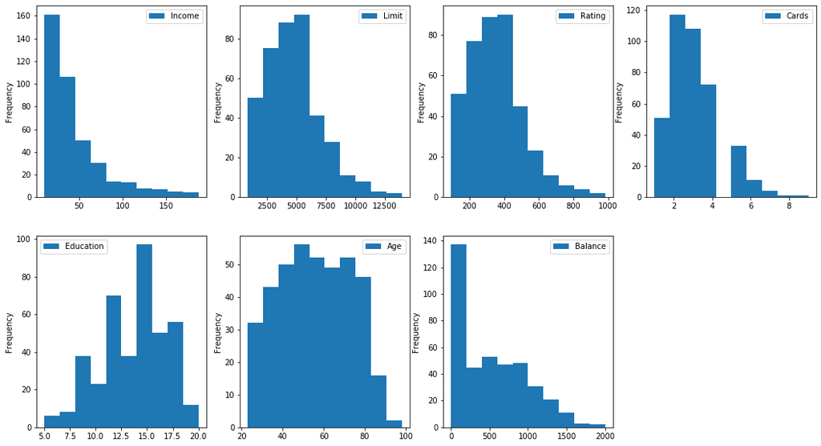

```python
plt.figure(figsize=(18,10))

plt.subplot(2,4,1)
d15['Income'].plot.hist()
plt.legend()

plt.subplot(2,4,2)
d15['Limit'].plot.hist()
plt.legend()

plt.subplot(2,4,3)
d15['Rating'].plot.hist()
plt.legend()

plt.subplot(2,4,4)
d15['Cards'].plot.hist()
plt.legend()

plt.subplot(2,4,5)
d15['Education'].plot.hist()
plt.legend()

plt.subplot(2,4,6)
d15['Age'].plot.hist()
plt.legend()

plt.subplot(2,4,7)
d15['Balance'].plot.hist()
plt.legend()

plt.show()
```

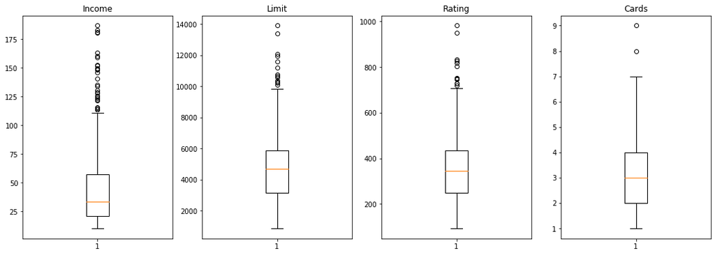

```python
plt.figure(figsize=(18,6))

plt.subplot(1,4,1)
plt.title('Income')
plt.boxplot(d12['Income'])

plt.subplot(1,4,2)
plt.title('Limit')
plt.boxplot(d12['Limit'])

plt.subplot(1,4,3)
plt.title('Rating')
plt.boxplot(d12['Rating'])

plt.subplot(1,4,4)
plt.title('Cards')
plt.boxplot(d12['Cards'])

plt.show()
```

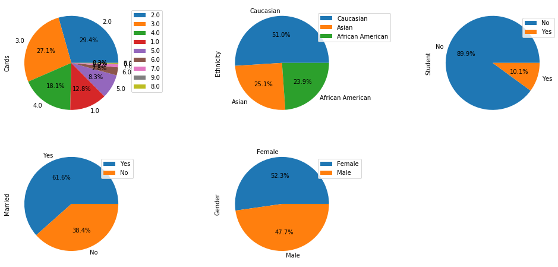

```python
plt.figure(figsize=(18,8))

plt.subplot(2,3,1)
d15['Cards'].value_counts().plot.pie(autopct='%1.1f%%')
plt.legend(loc='center right',bbox_to_anchor=(1.3, 0.6))

plt.subplot(2,3,2)
d15['Ethnicity'].value_counts().plot.pie(autopct='%1.1f%%')
plt.legend(loc='center right',bbox_to_anchor=(1.45, 0.8))

plt.subplot(2,3,3)
d12['Student'].value_counts().plot.pie(autopct='%1.1f%%')
plt.legend(loc='center right',bbox_to_anchor=(1.05, 0.8))

plt.subplot(2,3,4)
d12['Married'].value_counts().plot.pie(autopct='%1.1f%%')
plt.legend(loc='center right',bbox_to_anchor=(1.05, 0.8))

plt.subplot(2,3,5)
d12['Gender'].value_counts().plot.pie(autopct='%1.1f%%')
plt.legend(loc='center right',bbox_to_anchor=(1.2, 0.8))
plt.show()
```

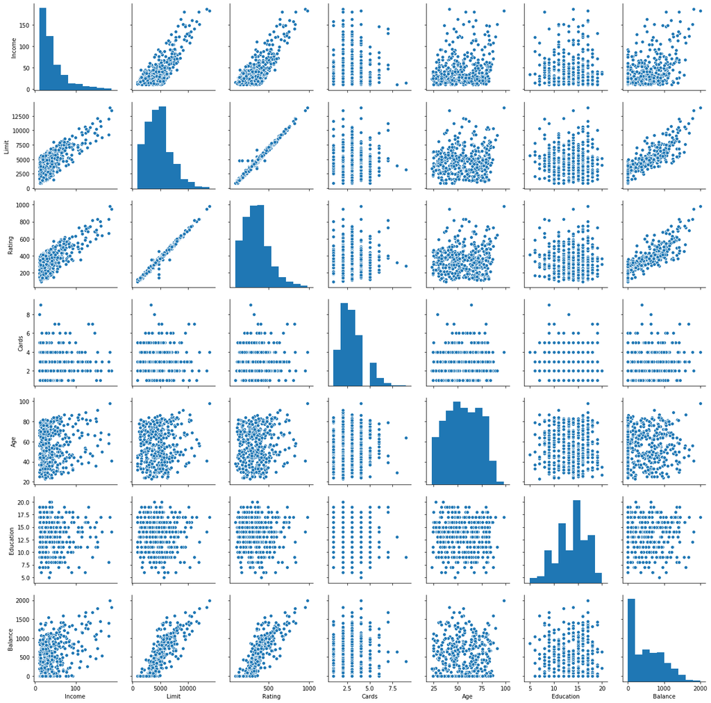

```python
import seaborn as sns

sns.pairplot(d12)
```

### Q.9. Values in column 'Income' are in the range of 10^4 while the values in column "Limit" in thousands. Create a derived column from these two columns

```python
d12['Income'].describe()
```

```
count    398.000000
mean      45.150744
std       35.172550
min       10.354000
25%       21.017750
50%       33.325500
75%       57.303250
max      186.634000
Name: Income, dtype: float64
```

```python
d12['Limit'].describe()
```

```
count      398.000000
mean      4754.820758
std       2297.631020
min        855.000000
25%       3161.250000
50%       4685.000000
75%       5860.000000
max      13913.000000
Name: Limit, dtype: float64
```

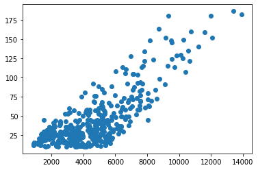

```python
plt.scatter(d12['Limit'],d12['Income'])
plt.show()
```

```python
d12['Net_Income']=((d12['Limit'])*60)/100   # adding new column by applying some function
d12
```

|  | Income | Limit | Rating | Cards | Age | Education | Gender | Student | Married | Ethnicity | Balance | Net_Income |
| --- | --- | --- | --- | --- | --- | --- | --- | --- | --- | --- | --- | --- |
| 0 | 14.891 | 3606.0 | 354.539043 | 2.0 | 34.0 | 11.0 | Male | No | Yes | Caucasian | 333.0 | 2163.6 |
| 1 | 106.025 | 6645.0 | 483.000000 | 3.0 | 82.0 | 15.0 | Female | Yes | Yes | Asian | 903.0 | 3987.0 |
| 2 | 104.593 | 7075.0 | 514.000000 | 4.0 | 71.0 | 11.0 | Male | No | No | Asian | 580.0 | 4245.0 |
| 3 | 148.924 | 9504.0 | 681.000000 | 3.0 | 36.0 | 11.0 | Female | No | No | Asian | 964.0 | 5702.4 |
| 4 | 55.882 | 4897.0 | 357.000000 | 2.0 | 68.0 | 16.0 | Male | No | Yes | Caucasian | 331.0 | 2938.2 |
| ... | ... | ... | ... | ... | ... | ... | ... | ... | ... | ... | ... | ... |
| 395 | 12.096 | 4100.0 | 307.000000 | 3.0 | 32.0 | 13.0 | Male | No | Yes | Caucasian | 560.0 | 2460.0 |
| 396 | 13.364 | 3838.0 | 296.000000 | 5.0 | 65.0 | 17.0 | Male | No | No | African American | 480.0 | 2302.8 |
| 397 | 57.872 | 4171.0 | 321.000000 | 5.0 | 67.0 | 12.0 | Female | No | Yes | Caucasian | 138.0 | 2502.6 |
| 398 | 37.728 | 2525.0 | 192.000000 | 1.0 | 44.0 | 13.0 | Male | No | Yes | Caucasian | 0.0 | 1515.0 |
| 399 | 18.701 | 5524.0 | 415.000000 | 5.0 | 64.0 | 7.0 | Female | No | No | Asian | 966.0 | 3314.4 |

398 rows × 12 columns

### Q.10. Which two variables are high correlated and which two features are least correlated?

```python
ans = d12.corr()
ans.style.background_gradient(cmap='gray')
```

|  | Income | Limit | Rating | Cards | Age | Education | Balance | Net_Income |
| --- | --- | --- | --- | --- | --- | --- | --- | --- |
| Income | 1 | 0.787357 | 0.784819 | -0.00903906 | 0.176577 | -0.0254374 | 0.460653 | 0.787357 |
| Limit | 0.787357 | 1 | 0.989735 | 0.0123166 | 0.103611 | -0.0235214 | 0.854408 | 1 |
| Rating | 0.784819 | 0.989735 | 1 | 0.0602775 | 0.11363 | -0.0280771 | 0.861971 | 0.989735 |
| Cards | -0.00903906 | 0.0123166 | 0.0602775 | 1 | 0.0343915 | -0.0530582 | 0.0952661 | 0.0123166 |
| Age | 0.176577 | 0.103611 | 0.11363 | 0.0343915 | 1 | -0.00681678 | 0.0100793 | 0.103611 |
| Education | -0.0254374 | -0.0235214 | -0.0280771 | -0.0530582 | -0.00681678 | 1 | -0.00400705 | -0.0235214 |
| Balance | 0.460653 | 0.854408 | 0.861971 | 0.0952661 | 0.0100793 | -0.00400705 | 1 | 0.854408 |
| Net_Income | 0.787357 | 1 | 0.989735 | 0.0123166 | 0.103611 | -0.0235214 | 0.854408 | 1 |

### Q.11. Is there any column that can be used as index? Show your findings

hence there is no column that have too unique values as we can take as index.

```python
d12.nunique()
```

```
Income        394
Limit         382
Rating        279
Cards           9
Age            68
Education      16
Gender          2
Student         2
Married         2
Ethnicity       3
Balance       283
Net_Income    382
dtype: int64
```

### Q.12. Create a new column Age_Group as per the following

```
Age     Age_Group
0-40       1
41-60      2
61-80      3
81-100     4
```

### and find:

```
a) which group have max number of cards ?
b) which group have max income?
c) Which group have minimum rating
```

```python
bins = [0, 40, 60, 80,100]
labels =[1,2,3,4]
d15['Age_Group'] = pd.cut(d15['Age'], bins,labels=labels)
d15
```

|  | Income | Limit | Rating | Cards | Age | Education | Gender | Student | Married | Ethnicity | Balance | N_age | Age_Group |
| --- | --- | --- | --- | --- | --- | --- | --- | --- | --- | --- | --- | --- | --- |
| 0 | 14.891 | 3606.0 | 354.539043 | 2.0 | 34.0 | 11.0 | Male | 0 | 1 | Caucasian | 333.0 | -1.259600 | 1 |
| 1 | 106.025 | 6645.0 | 483.000000 | 3.0 | 82.0 | 15.0 | Female | 1 | 1 | Asian | 903.0 | 1.523583 | 4 |
| 2 | 104.593 | 7075.0 | 514.000000 | 4.0 | 71.0 | 11.0 | Male | 0 | 0 | Asian | 580.0 | 0.885770 | 3 |
| 3 | 148.924 | 9504.0 | 681.000000 | 3.0 | 36.0 | 11.0 | Female | 0 | 0 | Asian | 964.0 | -1.143634 | 1 |
| 4 | 55.882 | 4897.0 | 357.000000 | 2.0 | 68.0 | 16.0 | Male | 0 | 1 | Caucasian | 331.0 | 0.711821 | 3 |
| ... | ... | ... | ... | ... | ... | ... | ... | ... | ... | ... | ... | ... | ... |
| 395 | 12.096 | 4100.0 | 307.000000 | 3.0 | 32.0 | 13.0 | Male | 0 | 1 | Caucasian | 560.0 | -1.375566 | 1 |
| 396 | 13.364 | 3838.0 | 296.000000 | 5.0 | 65.0 | 17.0 | Male | 0 | 0 | African American | 480.0 | 0.537872 | 3 |
| 397 | 57.872 | 4171.0 | 321.000000 | 5.0 | 67.0 | 12.0 | Female | 0 | 1 | Caucasian | 138.0 | 0.653838 | 3 |
| 398 | 37.728 | 2525.0 | 192.000000 | 1.0 | 44.0 | 13.0 | Male | 0 | 1 | Caucasian | 0.0 | -0.679770 | 2 |
| 399 | 18.701 | 5524.0 | 415.000000 | 5.0 | 64.0 | 7.0 | Female | 0 | 0 | Asian | 966.0 | 0.479889 | 3 |

398 rows × 13 columns

#### a) which group have max number of cards ?

```python
d33 =  d15.groupby('Age_Group')
d55 = d33['Cards'].value_counts()
d55
```

```
Age_Group  Cards
1          2.0      26
           3.0      21
           1.0      18
           4.0      17
           5.0       6
           7.0       2
           8.0       1
2          3.0      44
           2.0      35
           4.0      29
           1.0      17
           5.0      10
           6.0       6
           7.0       1
3          2.0      46
           3.0      31
           4.0      21
           5.0      15
           1.0      12
           6.0       5
           7.0       1
           9.0       1
4          3.0      12
           2.0      10
           4.0       5
           1.0       4
           5.0       2
Name: Cards, dtype: int64
```

#### b) which group have max income?

```python
d34 =  d15.groupby('Age_Group')
d56 = d34['Income'].max()
d56
```

```
Age_Group
1    148.924
2    186.634
3    180.379
4    182.728
Name: Income, dtype: float64
```

#### c) Which group have minimum rating

```python
d35 =  d15.groupby('Age_Group')
d57 = d35['Rating'].min()
d57
```

```
Age_Group
1     93.0
2    120.0
3    112.0
4    129.0
Name: Rating, dtype: float64
```

### Q.13. Which gender is more prominent under ‘Asian’ Ethnicity?

```python
# Which gender is more prominent under ‘Asian’ Ethnicity?


d13 = d15[(d15['Ethnicity']=='Asian')]
d13['Gender'].value_counts()
```

```
Female    54
Male      46
Name: Gender, dtype: int64
```

### Q.14. On an average, people belonging to which Ethnicity use their credit card more? (Base your calculations on "Limit" and "Balance")

```python
d39 =  d15.groupby(['Ethnicity'])
d80 = d39['Limit','Balance','Cards'].mean()
d80
```

| Ethnicity | Limit | Balance | Cards |
| --- | --- | --- | --- |
| African American | 4869.278575 | 528.989474 | 2.915789 |
| Asian | 4643.497323 | 512.080000 | 2.930000 |
| Caucasian | 4756.095885 | 518.921182 | 2.970443 |

### Q.15. For the following two questions you have to show your findings and visualize it too:

```
a) Number of cards issued to an individual is based on their ratings. Comment
b) Asians using credit cards are younger than African Americans
```

```python
# a) Number of cards issued to an individual is based on their ratings

d39 =  d15.groupby('Cards')
d79 = d39['Rating'].mean()
d79
```

```
Cards
1.0    355.137255
2.0    342.696915
3.0    355.987196
4.0    367.250000
5.0    331.787879
6.0    394.636364
7.0    580.000000
8.0    321.000000
9.0    282.000000
Name: Rating, dtype: float64
```

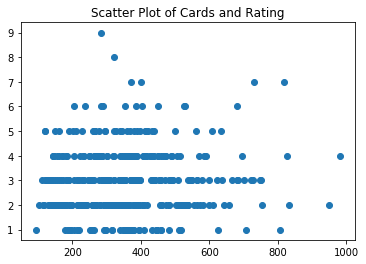

```python
plt.scatter(d15['Rating'],d15['Cards'])
plt.title('Scatter Plot of Cards and Rating')
plt.show()
```

```python
# b) Asians using credit cards are younger than African Americans

f2 = d15["Ethnicity"].isin(["Asian"])
f3 = d15["Ethnicity"].isin(["African American" ])
ff = d15[f2 | f3]
ff
```

|  | Income | Limit | Rating | Cards | Age | Education | Gender | Student | Married | Ethnicity | Balance | N_age | Age_Group |
| --- | --- | --- | --- | --- | --- | --- | --- | --- | --- | --- | --- | --- | --- |
| 1 | 106.025 | 6645.0 | 483.0 | 3.0 | 82.0 | 15.0 | Female | 1 | 1 | Asian | 903.0 | 1.523583 | 4 |
| 2 | 104.593 | 7075.0 | 514.0 | 4.0 | 71.0 | 11.0 | Male | 0 | 0 | Asian | 580.0 | 0.885770 | 3 |
| 3 | 148.924 | 9504.0 | 681.0 | 3.0 | 36.0 | 11.0 | Female | 0 | 0 | Asian | 964.0 | -1.143634 | 1 |
| 6 | 20.996 | 3388.0 | 259.0 | 2.0 | 37.0 | 12.0 | Female | 0 | 0 | African American | 203.0 | -1.085651 | 1 |
| 7 | 71.410 | 7114.0 | 512.0 | 2.0 | 87.0 | 9.0 | Male | 0 | 0 | Asian | 872.0 | 1.813498 | 4 |
| ... | ... | ... | ... | ... | ... | ... | ... | ... | ... | ... | ... | ... | ... |
| 390 | 135.118 | 10578.0 | 747.0 | 3.0 | 81.0 | 15.0 | Female | 0 | 1 | Asian | 1393.0 | 1.465600 | 4 |
| 392 | 25.974 | 2308.0 | 196.0 | 2.0 | 24.0 | 10.0 | Male | 0 | 0 | Asian | 0.0 | -1.839430 | 1 |
| 393 | 17.316 | 1335.0 | 138.0 | 2.0 | 65.0 | 13.0 | Male | 0 | 0 | African American | 0.0 | 0.537872 | 3 |
| 396 | 13.364 | 3838.0 | 296.0 | 5.0 | 65.0 | 17.0 | Male | 0 | 0 | African American | 480.0 | 0.537872 | 3 |
| 399 | 18.701 | 5524.0 | 415.0 | 5.0 | 64.0 | 7.0 | Female | 0 | 0 | Asian | 966.0 | 0.479889 | 3 |

195 rows × 13 columns

```python
nn = ff[ff['Ethnicity']=='African American'].Age_Group.value_counts()
nn
```

```
2    35
3    31
1    20
4     9
Name: Age_Group, dtype: int64
```

```python
mn = ff[ff['Ethnicity']=='Asian'].Age_Group.value_counts()
mn
```

```
2    37
3    32
1    25
4     6
Name: Age_Group, dtype: int64
```

```python
nnn = ff[ff['Ethnicity']=='African American']
mmn = ff[ff['Ethnicity']=='Asian']
```

```
<BarContainer object of 100 artists>
```

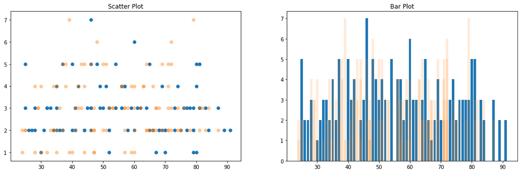

```python
# Plot graph of both group by Ethnicity an and age & Cards

plt.figure(figsize=(18,12))
plt.subplot(2,2,1)
plt.title('Scatter Plot')
plt.scatter(nnn['Age'],nnn['Cards'])
plt.scatter(mmn['Age'],mmn['Cards'],alpha=0.4)

plt.subplot(2,2,2)
plt.title('Bar Plot')
plt.bar(nnn['Age'],nnn['Cards'])
plt.bar(mmn['Age'],mmn['Cards'],alpha=0.15)
```

*** END ***